# Predict Bike Sharing Demand with AutoGluon Template

## Project: Predict Bike Sharing Demand with AutoGluon

This notebook is a template with each step that you need to complete for the project.

Please fill in your code where there are explicit `?` markers in the notebook. You are welcome to add more cells and code as you see fit.

Once you have completed all the code implementations, please export your notebook as a HTML file so the reviews can view your code. Make sure you have all outputs correctly outputted.

`File-> Export Notebook As... -> Export Notebook as HTML`

There is a writeup to complete as well after all code implememtation is done. Please answer all questions and attach the necessary tables and charts. You can complete the writeup in either markdown or PDF.

Completing the code template and writeup template will cover all of the rubric points for this project.

The rubric contains "Stand Out Suggestions" for enhancing the project beyond the minimum requirements. The stand out suggestions are optional. If you decide to pursue the "stand out suggestions", you can include the code in this notebook and also discuss the results in the writeup file.

## Step 1: Create an account with Kaggle

### Create Kaggle Account and download API key

## Step 2: Download the Kaggle dataset using the kaggle python library

### Open up Sagemaker Studio and use starter template

1. Notebook should be using a `ml.t3.medium` instance (2 vCPU + 4 GiB)
2. Notebook should be using kernal: `Python 3 (MXNet 1.8 Python 3.7 CPU Optimized)`

### Install packages

```python
!pip install -U pip
!pip install -U setuptools wheel
!pip install -U mxnet bokeh
!pip install autogluon --no-cache-dir
# Without --no-cache-dir, smaller aws instances may have trouble installing
```

[output not shown]

### Setup Kaggle API Key

```python
# create the .kaggle directory and an empty kaggle.json file
!mkdir -p /root/.kaggle
!touch /root/.kaggle/kaggle.json
!chmod 600 /root/.kaggle/kaggle.json
```

```python
# Fill in your user name and key from creating the kaggle account and API token file
import json
kaggle_username = "aikorkemizimova"
kaggle_key = "9d276eb5940cd5b630390fe202f7514b"

# Save API token the kaggle.json file
with open("/root/.kaggle/kaggle.json", "w") as f:
    f.write(json.dumps({"username": kaggle_username, "key": kaggle_key}))
```

### Download and explore dataset

### Go to the bike sharing demand competition and agree to the terms

```python
# Download the dataset, it will be in a .zip file so you'll need to unzip it as well.
!kaggle competitions download -c bike-sharing-demand
# If you already downloaded it you can use the -o command to overwrite the file
!unzip -o bike-sharing-demand.zip
```

```
bike-sharing-demand.zip: Skipping, found more recently modified local copy (use --force to force download)
Archive:  bike-sharing-demand.zip
  inflating: sampleSubmission.csv
  inflating: test.csv
  inflating: train.csv
```

```python
import pandas as pd
from autogluon.tabular import TabularPredictor
```

```python
# Create the train dataset in pandas by reading the csv
# Set the parsing of the datetime column so you can use some of the `dt` features in pandas later
train = pd.read_csv("train.csv", parse_dates=["datetime"])
train.head()
```

|  | datetime | season | holiday | workingday | weather | temp | atemp | humidity | windspeed | casual | registered | count |
| --- | --- | --- | --- | --- | --- | --- | --- | --- | --- | --- | --- | --- |
| 0 | 2011-01-01 00:00:00 | 1 | 0 | 0 | 1 | 9.84 | 14.395 | 81 | 0.0 | 3 | 13 | 16 |
| 1 | 2011-01-01 01:00:00 | 1 | 0 | 0 | 1 | 9.02 | 13.635 | 80 | 0.0 | 8 | 32 | 40 |
| 2 | 2011-01-01 02:00:00 | 1 | 0 | 0 | 1 | 9.02 | 13.635 | 80 | 0.0 | 5 | 27 | 32 |
| 3 | 2011-01-01 03:00:00 | 1 | 0 | 0 | 1 | 9.84 | 14.395 | 75 | 0.0 | 3 | 10 | 13 |
| 4 | 2011-01-01 04:00:00 | 1 | 0 | 0 | 1 | 9.84 | 14.395 | 75 | 0.0 | 0 | 1 | 1 |

```python
# Simple output of the train dataset to view some of the min/max/varition of the dataset features.
train.describe(include='all')
```

|  | datetime | season | holiday | workingday | weather | temp | atemp | humidity | windspeed | casual | registered | count |
| --- | --- | --- | --- | --- | --- | --- | --- | --- | --- | --- | --- | --- |
| count | 10886 | 10886.000000 | 10886.000000 | 10886.000000 | 10886.000000 | 10886.00000 | 10886.000000 | 10886.000000 | 10886.000000 | 10886.000000 | 10886.000000 | 10886.000000 |
| mean | 2011-12-27 05:56:22.399411968 | 2.506614 | 0.028569 | 0.680875 | 1.418427 | 20.23086 | 23.655084 | 61.886460 | 12.799395 | 36.021955 | 155.552177 | 191.574132 |
| min | 2011-01-01 00:00:00 | 1.000000 | 0.000000 | 0.000000 | 1.000000 | 0.82000 | 0.760000 | 0.000000 | 0.000000 | 0.000000 | 0.000000 | 1.000000 |
| 25% | 2011-07-02 07:15:00 | 2.000000 | 0.000000 | 0.000000 | 1.000000 | 13.94000 | 16.665000 | 47.000000 | 7.001500 | 4.000000 | 36.000000 | 42.000000 |
| 50% | 2012-01-01 20:30:00 | 3.000000 | 0.000000 | 1.000000 | 1.000000 | 20.50000 | 24.240000 | 62.000000 | 12.998000 | 17.000000 | 118.000000 | 145.000000 |
| 75% | 2012-07-01 12:45:00 | 4.000000 | 0.000000 | 1.000000 | 2.000000 | 26.24000 | 31.060000 | 77.000000 | 16.997900 | 49.000000 | 222.000000 | 284.000000 |
| max | 2012-12-19 23:00:00 | 4.000000 | 1.000000 | 1.000000 | 4.000000 | 41.00000 | 45.455000 | 100.000000 | 56.996900 | 367.000000 | 886.000000 | 977.000000 |
| std | NaN | 1.116174 | 0.166599 | 0.466159 | 0.633839 | 7.79159 | 8.474601 | 19.245033 | 8.164537 | 49.960477 | 151.039033 | 181.144454 |

```python
train.info()
train.isnull().sum()
```

```
<class 'pandas.core.frame.DataFrame'>
RangeIndex: 10886 entries, 0 to 10885
Data columns (total 12 columns):
 #   Column      Non-Null Count  Dtype
---  ------      --------------  -----
 0   datetime    10886 non-null  datetime64[ns]
 1   season      10886 non-null  int64
 2   holiday     10886 non-null  int64
 3   workingday  10886 non-null  int64
 4   weather     10886 non-null  int64
 5   temp        10886 non-null  float64
 6   atemp       10886 non-null  float64
 7   humidity    10886 non-null  int64
 8   windspeed   10886 non-null  float64
 9   casual      10886 non-null  int64
 10  registered  10886 non-null  int64
 11  count       10886 non-null  int64
dtypes: datetime64[ns](1), float64(3), int64(8)
memory usage: 1020.7 KB
```

|  | 0 |
| --- | --- |
| datetime | 0 |
| season | 0 |
| holiday | 0 |
| workingday | 0 |
| weather | 0 |
| temp | 0 |
| atemp | 0 |
| humidity | 0 |
| windspeed | 0 |
| casual | 0 |
| registered | 0 |
| count | 0 |

**dtype:** int64

```python
# Create the test pandas dataframe in pandas by reading the csv, remember to parse the datetime!
test = pd.read_csv("test.csv", parse_dates=["datetime"])
test.head()
```

|  | datetime | season | holiday | workingday | weather | temp | atemp | humidity | windspeed |
| --- | --- | --- | --- | --- | --- | --- | --- | --- | --- |
| 0 | 2011-01-20 00:00:00 | 1 | 0 | 1 | 1 | 10.66 | 11.365 | 56 | 26.0027 |
| 1 | 2011-01-20 01:00:00 | 1 | 0 | 1 | 1 | 10.66 | 13.635 | 56 | 0.0000 |
| 2 | 2011-01-20 02:00:00 | 1 | 0 | 1 | 1 | 10.66 | 13.635 | 56 | 0.0000 |
| 3 | 2011-01-20 03:00:00 | 1 | 0 | 1 | 1 | 10.66 | 12.880 | 56 | 11.0014 |
| 4 | 2011-01-20 04:00:00 | 1 | 0 | 1 | 1 | 10.66 | 12.880 | 56 | 11.0014 |

```python
test.info()
test.isnull().sum()
```

```
<class 'pandas.core.frame.DataFrame'>
RangeIndex: 6493 entries, 0 to 6492
Data columns (total 9 columns):
 #   Column      Non-Null Count  Dtype
---  ------      --------------  -----
 0   datetime    6493 non-null   datetime64[ns]
 1   season      6493 non-null   int64
 2   holiday     6493 non-null   int64
 3   workingday  6493 non-null   int64
 4   weather     6493 non-null   int64
 5   temp        6493 non-null   float64
 6   atemp       6493 non-null   float64
 7   humidity    6493 non-null   int64
 8   windspeed   6493 non-null   float64
dtypes: datetime64[ns](1), float64(3), int64(5)
memory usage: 456.7 KB
```

|  | 0 |
| --- | --- |
| datetime | 0 |
| season | 0 |
| holiday | 0 |
| workingday | 0 |
| weather | 0 |
| temp | 0 |
| atemp | 0 |
| humidity | 0 |
| windspeed | 0 |

**dtype:** int64

```python
# Same thing as train and test dataset
submission = pd.read_csv("sampleSubmission.csv")
submission.head()
```

|  | datetime | count |
| --- | --- | --- |
| 0 | 2011-01-20 00:00:00 | 0 |
| 1 | 2011-01-20 01:00:00 | 0 |
| 2 | 2011-01-20 02:00:00 | 0 |
| 3 | 2011-01-20 03:00:00 | 0 |
| 4 | 2011-01-20 04:00:00 | 0 |

## Data Fields

**datetime** - hourly date + timestamp

**season** - 1 = spring, 2 = summer, 3 = fall, 4 = winter

**holiday** - whether the day is considered a holiday

**workingday** - whether the day is neither a weekend nor holiday

**weather** -

```
1: Clear, Few clouds, Partly cloudy, Partly cloudy
2: Mist + Cloudy, Mist + Broken clouds, Mist + Few clouds, Mist
3: Light Snow, Light Rain + Thunderstorm + Scattered clouds, Light Rain + Scattered clouds
4: Heavy Rain + Ice Pallets + Thunderstorm + Mist, Snow + Fog
```

**temp** - temperature in Celsius

**atemp** - "feels like" temperature in Celsius

**humidity** - relative humidity

**windspeed** - wind speed

**casual** - number of non-registered user rentals initiated (ignored)

**registered** - number of registered user rentals initiated (ignored)

**count** - number of total rentals

## Step 3: Train a model using AutoGluon’s Tabular Prediction

Requirements:

- We are prediting `count`, so it is the label we are setting.
- Ignore `casual` and `registered` columns as they are also not present in the test dataset.
- Use the `root_mean_squared_error` as the metric to use for evaluation.
- Set a time limit of 10 minutes (600 seconds).
- Use the preset `best_quality` to focus on creating the best model.

```python
label = 'count'
train_data = train.drop(columns=['casual', 'registered'])
```

```python
predictor = TabularPredictor(label=label, eval_metric='root_mean_squared_error').fit(
    train_data=train_data,
    time_limit=600,
    presets='best_quality'
)
```

[output not shown]

[output cut: 33 more lines]

```
(_dystack pid=18612) 	'XT': [{'criterion': 'gini', 'ag_args': {'name_suffix': 'Gini', 'problem_types': ['binary', 'multiclass']}}, {'criterion': 'entropy', 'ag_args': {'name_suffix': 'Entr', 'problem_types': ['binary', 'multiclass']}}, {'criterion': 'squared_error', 'ag_args': {'name_suffix': 'MSE',…
(_dystack pid=18612) 	'KNN': [{'weights': 'uniform', 'ag_args': {'name_suffix': 'Unif'}}, {'weights': 'distance', 'ag_args': {'name_suffix': 'Dist'}}],
(_dystack pid=18612) }
(_dystack pid=18612) AutoGluon will fit 2 stack levels (L1 to L2) ...
(_dystack pid=18612) Fitting 108 L1 models, fit_strategy="sequential" ...
(_dystack pid=18612) Fitting model: KNeighborsUnif_BAG_L1 ... Training model for up to 94.06s of the 141.03s of remaining time.
(_dystack pid=18612) 	-107.445	 = Validation score   (-root_mean_squared_error)
(_dystack pid=18612) 	0.04s	 = Training   runtime
(_dystack pid=18612) 	0.07s	 = Validation runtime
(_dystack pid=18612) Fitting model: KNeighborsDist_BAG_L1 ... Training model for up to 87.95s of the 134.92s of remaining time.
(_dystack pid=18612) 	-89.9469	 = Validation score   (-root_mean_squared_error)
(_dystack pid=18612) 	0.02s	 = Training   runtime
(_dystack pid=18612) 	0.06s	 = Validation runtime
(_dystack pid=18612) Fitting model: LightGBMXT_BAG_L1 ... Training model for up to 87.86s of the 134.83s of remaining time.
(_dystack pid=18612) 	Fitting 8 child models (S1F1 - S1F8) | Fitting with ParallelLocalFoldFittingStrategy (2 workers, per: cpus=1, gpus=0, memory=0.10%)
```

```
(_ray_fit pid=18801) [1000]	valid_set's rmse: 129.692
(_ray_fit pid=18994) [1000]	valid_set's rmse: 132.725 [repeated 5x across cluster] (Ray deduplicates logs by default. Set RAY_DEDUP_LOGS=0 to disable log deduplication, or see https://docs.ray.io/en/master/ray-observability/user-guides/configure-logging.html#log-deduplication for more options.)
(_ray_fit pid=19046) [1000]	valid_set's rmse: 128.154
(_ray_fit pid=19046) [2000]	valid_set's rmse: 126.702
(_ray_fit pid=19046) [3000]	valid_set's rmse: 126.147
(_ray_fit pid=19046) [4000]	valid_set's rmse: 125.904
(_ray_fit pid=19115) [1000]	valid_set's rmse: 135.845
(_ray_fit pid=19046) [5000]	valid_set's rmse: 125.681
(_ray_fit pid=19115) [4000]	valid_set's rmse: 133.013 [repeated 5x across cluster]
```

```
(_ray_fit pid=19046) 	Ran out of time, early stopping on iteration 7999. Best iteration is:
(_ray_fit pid=19046) 	[7106]	valid_set's rmse: 125.339
```

```
(_ray_fit pid=19115) [8000]	valid_set's rmse: 132.379 [repeated 4x across cluster]
```

```
(_ray_fit pid=19115) 	Ran out of time, early stopping on iteration 9415. Best iteration is:
(_ray_fit pid=19115) 	[7329]	valid_set's rmse: 132.331
```

```
(_ray_fit pid=19243) [1000]	valid_set's rmse: 137.712 [repeated 2x across cluster]
(_ray_fit pid=19243) [4000]	valid_set's rmse: 135.344 [repeated 3x across cluster]
(_ray_fit pid=19243) [7000]	valid_set's rmse: 135.236 [repeated 4x across cluster]
(_ray_fit pid=19321) [5000]	valid_set's rmse: 137.961 [repeated 5x across cluster]
```

```
(_dystack pid=18612) 	-131.9758	 = Validation score   (-root_mean_squared_error)
(_dystack pid=18612) 	84.77s	 = Training   runtime
(_dystack pid=18612) 	9.71s	 = Validation runtime
(_dystack pid=18612) Fitting model: WeightedEnsemble_L2 ... Training model for up to 141.13s of the 43.95s of remaining time.
(_dystack pid=18612) 	Ensemble Weights: {'KNeighborsDist_BAG_L1': 1.0}
(_dystack pid=18612) 	-89.9469	 = Validation score   (-root_mean_squared_error)
(_dystack pid=18612) 	0.02s	 = Training   runtime
(_dystack pid=18612) 	0.0s	 = Validation runtime
(_dystack pid=18612) Fitting 106 L2 models, fit_strategy="sequential" ...
(_dystack pid=18612) Fitting model: LightGBMXT_BAG_L2 ... Training model for up to 43.92s of the 43.69s of remaining time.
(_dystack pid=18612) 	Fitting 8 child models (S1F1 - S1F8) | Fitting with ParallelLocalFoldFittingStrategy (2 workers, per: cpus=1, gpus=0, memory=0.12%)
```

```
(_ray_fit pid=19442) [1000]	valid_set's rmse: 71.4318
(_ray_fit pid=19443) [1000]	valid_set's rmse: 70.3611
(_ray_fit pid=19551) [1000]	valid_set's rmse: 77.4878
(_ray_fit pid=19585) [1000]	valid_set's rmse: 73.7739
(_ray_fit pid=19675) [1000]	valid_set's rmse: 76.4032
(_ray_fit pid=19676) [1000]	valid_set's rmse: 77.0022
(_ray_fit pid=19789) [1000]	valid_set's rmse: 73.4134
(_ray_fit pid=19828) [1000]	valid_set's rmse: 75.8094
```

```
(_dystack pid=18612) 	-74.3067	 = Validation score   (-root_mean_squared_error)
(_dystack pid=18612) 	46.23s	 = Training   runtime
(_dystack pid=18612) 	2.24s	 = Validation runtime
(_dystack pid=18612) Fitting model: WeightedEnsemble_L3 ... Training model for up to 141.13s of the -8.21s of remaining time.
(_dystack pid=18612) 	Ensemble Weights: {'LightGBMXT_BAG_L2': 0.947, 'KNeighborsDist_BAG_L1': 0.053}
(_dystack pid=18612) 	-74.2555	 = Validation score   (-root_mean_squared_error)
(_dystack pid=18612) 	0.01s	 = Training   runtime
(_dystack pid=18612) 	0.0s	 = Validation runtime
(_dystack pid=18612) AutoGluon training complete, total runtime = 149.46s ... Best model: WeightedEnsemble_L3 | Estimated inference throughput: 101.1 rows/s (1210 batch size)
(_dystack pid=18612) TabularPredictor saved. To load, use: predictor = TabularPredictor.load("/content/AutogluonModels/ag-20250608_162428/ds_sub_fit/sub_fit_ho")
(_dystack pid=18612) Deleting DyStack predictor artifacts (clean_up_fits=True) ...
Leaderboard on holdout data (DyStack):
                   model  score_holdout   score_val              eval_metric  pred_time_test  pred_time_val    fit_time  pred_time_test_marginal  pred_time_val_marginal  fit_time_marginal  stack_level  can_infer  fit_order
0      LightGBMXT_BAG_L2     -72.615295  -74.306707  root_mean_squared_error       14.018041      12.074802  131.050867                 1.743265                2.242529          46.229566            2       True          5
1    WeightedEnsemble_L3     -72.747027  -74.255475  root_mean_squared_error       14.020523      12.075374  131.064141                 0.002482                0.000571           0.013275            3       True          6
2  KNeighborsDist_BAG_L1     -92.031272  -89.946854  root_mean_squared_error        0.015486       0.060055    0.017750                 0.015486                0.060055           0.017750            1       True          2
3    WeightedEnsemble_L2     -92.031272  -89.946854  root_mean_squared_error        0.019345       0.060921    0.036777                 0.003859                0.000866           0.019027            2       True          4
4  KNeighborsUnif_BAG_L1    -109.161488 -107.445008  root_mean_squared_error        0.015673       0.066473    0.036538                 0.015673                0.066473           0.036538            1       True          1
5      LightGBMXT_BAG_L1    -131.068281 -131.975832  root_mean_squared_error       12.243617       9.705745   84.767013                12.243617                9.705745          84.767013            1       True          3
	1	 = Optimal   num_stack_levels (Stacked Overfitting Occurred: False)
	175s	 = DyStack   runtime |	425s	 = Remaining runtime
Starting main fit with num_stack_levels=1.
	For future fit calls on this dataset, you can skip DyStack to save time: `predictor.fit(..., dynamic_stacking=False, num_stack_levels=1)`
Beginning AutoGluon training ... Time limit = 425s
AutoGluon will save models to "/content/AutogluonModels/ag-20250608_162428"
Train Data Rows:    10886
Train Data Columns: 9
Label Column:       count
Problem Type:       regression
Preprocessing data ...
Using Feature Generators to preprocess the data ...
Fitting AutoMLPipelineFeatureGenerator...
	Available Memory:                    10844.57 MB
	Train Data (Original)  Memory Usage: 0.75 MB (0.0% of available memory)
	Inferring data type of each feature based on column values. Set feature_metadata_in to manually specify special dtypes of the features.
	Stage 1 Generators:
		Fitting AsTypeFeatureGenerator...
			Note: Converting 2 features to boolean dtype as they only contain 2 unique values.
	Stage 2 Generators:
		Fitting FillNaFeatureGenerator...
```

[output cut: 80 more lines]

```
	Fitting 8 child models (S1F1 - S1F8) | Fitting with ParallelLocalFoldFittingStrategy (2 workers, per: cpus=1, gpus=0, memory=0.14%)
	-54.971	 = Validation score   (-root_mean_squared_error)
	35.66s	 = Training   runtime
	0.43s	 = Validation runtime
Fitting model: RandomForestMSE_BAG_L2 ... Training model for up to 18.50s of the 18.47s of remaining time.
	-53.4391	 = Validation score   (-root_mean_squared_error)
	46.18s	 = Training   runtime
	0.97s	 = Validation runtime
Fitting model: WeightedEnsemble_L3 ... Training model for up to 360.00s of the -30.78s of remaining time.
	Ensemble Weights: {'RandomForestMSE_BAG_L2': 0.708, 'LightGBM_BAG_L2': 0.25, 'LightGBMXT_BAG_L2': 0.042}
	-53.1033	 = Validation score   (-root_mean_squared_error)
	0.05s	 = Training   runtime
	0.0s	 = Validation runtime
AutoGluon training complete, total runtime = 455.73s ... Best model: WeightedEnsemble_L3 | Estimated inference throughput: 63.6 rows/s (1361 batch size)
TabularPredictor saved. To load, use: predictor = TabularPredictor.load("/content/AutogluonModels/ag-20250608_162428")
```

### Review AutoGluon's training run with ranking of models that did the best.

```python
predictor.fit_summary()
```

```
*** Summary of fit() ***
Estimated performance of each model:
                     model   score_val              eval_metric  pred_time_val    fit_time  pred_time_val_marginal  fit_time_marginal  stack_level  can_infer  fit_order
0      WeightedEnsemble_L3  -53.103332  root_mean_squared_error      23.407214  414.029263                0.000694           0.045359            3       True         12
1   RandomForestMSE_BAG_L2  -53.439057  root_mean_squared_error      17.450211  310.920178                0.972195          46.183577            2       True         11
2          LightGBM_BAG_L2  -54.971036  root_mean_squared_error      16.910534  300.399932                0.432518          35.663330            2       True         10
3        LightGBMXT_BAG_L2  -60.430075  root_mean_squared_error      22.001807  332.136997                5.523791          67.400396            2       True          9
4    KNeighborsDist_BAG_L1  -84.125061  root_mean_squared_error       0.056220    0.034240                0.056220           0.034240            1       True          2
5      WeightedEnsemble_L2  -84.125061  root_mean_squared_error       0.056889    0.059401                0.000669           0.025160            2       True          8
6    KNeighborsUnif_BAG_L1 -101.546199  root_mean_squared_error       0.056739    0.038450                0.056739           0.038450            1       True          1
7   RandomForestMSE_BAG_L1 -116.548359  root_mean_squared_error       0.597412   18.289075                0.597412          18.289075            1       True          5
8     ExtraTreesMSE_BAG_L1 -124.600676  root_mean_squared_error       0.595010    9.109461                0.595010           9.109461            1       True          7
9          CatBoost_BAG_L1 -130.865267  root_mean_squared_error       0.125731  115.041701                0.125731         115.041701            1       True          6
10         LightGBM_BAG_L1 -131.054162  root_mean_squared_error       1.797518   41.097772                1.797518          41.097772            1       True          4
11       LightGBMXT_BAG_L1 -131.460909  root_mean_squared_error      13.249387   81.125903               13.249387          81.125903            1       True          3
Number of models trained: 12
Types of models trained:
{'StackerEnsembleModel_CatBoost', 'WeightedEnsembleModel', 'StackerEnsembleModel_RF', 'StackerEnsembleModel_LGB', 'StackerEnsembleModel_XT', 'StackerEnsembleModel_KNN'}
Bagging used: True  (with 8 folds)
Multi-layer stack-ensembling used: True  (with 3 levels)
Feature Metadata (Processed):
(raw dtype, special dtypes):
('float', [])                : 3 | ['temp', 'atemp', 'windspeed']
('int', [])                  : 3 | ['season', 'weather', 'humidity']
('int', ['bool'])            : 2 | ['holiday', 'workingday']
('int', ['datetime_as_int']) : 5 | ['datetime', 'datetime.year', 'datetime.month', 'datetime.day', 'datetime.dayofweek']
Plot summary of models saved to file: /content/AutogluonModels/ag-20250608_162428/SummaryOfModels.html
*** End of fit() summary ***
```

```
{'model_types': {'KNeighborsUnif_BAG_L1': 'StackerEnsembleModel_KNN',
  'KNeighborsDist_BAG_L1': 'StackerEnsembleModel_KNN',
  'LightGBMXT_BAG_L1': 'StackerEnsembleModel_LGB',
  'LightGBM_BAG_L1': 'StackerEnsembleModel_LGB',
  'RandomForestMSE_BAG_L1': 'StackerEnsembleModel_RF',
  'CatBoost_BAG_L1': 'StackerEnsembleModel_CatBoost',
  'ExtraTreesMSE_BAG_L1': 'StackerEnsembleModel_XT',
  'WeightedEnsemble_L2': 'WeightedEnsembleModel',
  'LightGBMXT_BAG_L2': 'StackerEnsembleModel_LGB',
  'LightGBM_BAG_L2': 'StackerEnsembleModel_LGB',
  'RandomForestMSE_BAG_L2': 'StackerEnsembleModel_RF',
  'WeightedEnsemble_L3': 'WeightedEnsembleModel'},
 'model_performance': {'KNeighborsUnif_BAG_L1': np.float64(-101.54619908446061),
  'KNeighborsDist_BAG_L1': np.float64(-84.12506123181602),
  'LightGBMXT_BAG_L1': np.float64(-131.46090891834504),
  'LightGBM_BAG_L1': np.float64(-131.054161598899),
  'RandomForestMSE_BAG_L1': np.float64(-116.54835939455667),
  'CatBoost_BAG_L1': np.float64(-130.86526693284344),
  'ExtraTreesMSE_BAG_L1': np.float64(-124.60067564699747),
  'WeightedEnsemble_L2': np.float64(-84.12506123181602),
  'LightGBMXT_BAG_L2': np.float64(-60.43007471992891),
  'LightGBM_BAG_L2': np.float64(-54.97103611238515),
  'RandomForestMSE_BAG_L2': np.float64(-53.43905667070135),
  'WeightedEnsemble_L3': np.float64(-53.103331653668754)},
 'model_best': 'WeightedEnsemble_L3',
 'model_paths': {'KNeighborsUnif_BAG_L1': ['KNeighborsUnif_BAG_L1'],
  'KNeighborsDist_BAG_L1': ['KNeighborsDist_BAG_L1'],
  'LightGBMXT_BAG_L1': ['LightGBMXT_BAG_L1'],
  'LightGBM_BAG_L1': ['LightGBM_BAG_L1'],
  'RandomForestMSE_BAG_L1': ['RandomForestMSE_BAG_L1'],
  'CatBoost_BAG_L1': ['CatBoost_BAG_L1'],
  'ExtraTreesMSE_BAG_L1': ['ExtraTreesMSE_BAG_L1'],
  'WeightedEnsemble_L2': ['WeightedEnsemble_L2'],
  'LightGBMXT_BAG_L2': ['LightGBMXT_BAG_L2'],
  'LightGBM_BAG_L2': ['LightGBM_BAG_L2'],
  'RandomForestMSE_BAG_L2': ['RandomForestMSE_BAG_L2'],
  'WeightedEnsemble_L3': ['WeightedEnsemble_L3']},
 'model_fit_times': {'KNeighborsUnif_BAG_L1': 0.03844952583312988,
  'KNeighborsDist_BAG_L1': 0.0342404842376709,
  'LightGBMXT_BAG_L1': 81.12590265274048,
```

[output cut: 150 more lines]

```
 11      13.249387   81.125903               13.249387          81.125903

     stack_level  can_infer  fit_order
 0             3       True         12
 1             2       True         11
 2             2       True         10
 3             2       True          9
 4             1       True          2
 5             2       True          8
 6             1       True          1
 7             1       True          5
 8             1       True          7
 9             1       True          6
 10            1       True          4
 11            1       True          3  }
```

```python
leaderboard_df = pd.DataFrame(predictor.leaderboard(silent=True))
leaderboard_df
```

|  | model | score_val | eval_metric | pred_time_val | fit_time | pred_time_val_marginal | fit_time_marginal | stack_level | can_infer | fit_order |
| --- | --- | --- | --- | --- | --- | --- | --- | --- | --- | --- |
| 0 | WeightedEnsemble_L3 | -53.103332 | root_mean_squared_error | 23.407214 | 414.029263 | 0.000694 | 0.045359 | 3 | True | 12 |
| 1 | RandomForestMSE_BAG_L2 | -53.439057 | root_mean_squared_error | 17.450211 | 310.920178 | 0.972195 | 46.183577 | 2 | True | 11 |
| 2 | LightGBM_BAG_L2 | -54.971036 | root_mean_squared_error | 16.910534 | 300.399932 | 0.432518 | 35.663330 | 2 | True | 10 |
| 3 | LightGBMXT_BAG_L2 | -60.430075 | root_mean_squared_error | 22.001807 | 332.136997 | 5.523791 | 67.400396 | 2 | True | 9 |
| 4 | KNeighborsDist_BAG_L1 | -84.125061 | root_mean_squared_error | 0.056220 | 0.034240 | 0.056220 | 0.034240 | 1 | True | 2 |
| 5 | WeightedEnsemble_L2 | -84.125061 | root_mean_squared_error | 0.056889 | 0.059401 | 0.000669 | 0.025160 | 2 | True | 8 |
| 6 | KNeighborsUnif_BAG_L1 | -101.546199 | root_mean_squared_error | 0.056739 | 0.038450 | 0.056739 | 0.038450 | 1 | True | 1 |
| 7 | RandomForestMSE_BAG_L1 | -116.548359 | root_mean_squared_error | 0.597412 | 18.289075 | 0.597412 | 18.289075 | 1 | True | 5 |
| 8 | ExtraTreesMSE_BAG_L1 | -124.600676 | root_mean_squared_error | 0.595010 | 9.109461 | 0.595010 | 9.109461 | 1 | True | 7 |
| 9 | CatBoost_BAG_L1 | -130.865267 | root_mean_squared_error | 0.125731 | 115.041701 | 0.125731 | 115.041701 | 1 | True | 6 |
| 10 | LightGBM_BAG_L1 | -131.054162 | root_mean_squared_error | 1.797518 | 41.097772 | 1.797518 | 41.097772 | 1 | True | 4 |
| 11 | LightGBMXT_BAG_L1 | -131.460909 | root_mean_squared_error | 13.249387 | 81.125903 | 13.249387 | 81.125903 | 1 | True | 3 |

### Create predictions from test dataset

```python
predictions = predictor.predict(test)
predictions.head()
```

|  | count |
| --- | --- |
| 0 | 23.414099 |
| 1 | 42.682716 |
| 2 | 45.675728 |
| 3 | 48.559208 |
| 4 | 51.085991 |

**dtype:** float32

#### NOTE: Kaggle will reject the submission if we don't set everything to be > 0.

```python
# Describe the `predictions` series to see if there are any negative values
predictions.describe()
```

|  | count |
| --- | --- |
| count | 6493.000000 |
| mean | 100.527763 |
| std | 89.986191 |
| min | 2.960000 |
| 25% | 19.760393 |
| 50% | 64.005028 |
| 75% | 167.550751 |
| max | 368.407318 |

**dtype:** float64

```python
# How many negative values do we have?
(predictions < 0).sum()
```

```
np.int64(0)
```

```python
# Set them to zero
predictions[predictions < 0] = 0
```

### Set predictions to submission dataframe, save, and submit

```python
submission["count"] = predictions
submission.to_csv("submission.csv", index=False)
```

```python
!kaggle competitions submit -c bike-sharing-demand -f submission.csv -m "first raw submission"
```

```
100% 188k/188k [00:01<00:00, 191kB/s]
Successfully submitted to Bike Sharing Demand
```

#### View submission via the command line or in the web browser under the competition's page - `My Submissions`

```python
!kaggle competitions submissions -c bike-sharing-demand | tail -n +1 | head -n 6
```

```
fileName                     date                        description                          status                     publicScore  privateScore
---------------------------  --------------------------  -----------------------------------  -------------------------  -----------  ------------
submission.csv               2025-06-08 16:36:07.093000  first raw submission                 SubmissionStatus.COMPLETE  1.80714      1.80714
submission_new_hpo3.csv      2025-06-07 22:19:23.107000  new features with hyperparameters 3  SubmissionStatus.COMPLETE  0.47284      0.47284
submission_new_hpo2.csv      2025-06-07 22:07:04.210000  new features with hyperparameters 2  SubmissionStatus.COMPLETE  0.47384      0.47384
submission_new_hpo.csv       2025-06-07 21:55:58.837000  new features with hyperparameters    SubmissionStatus.COMPLETE  0.49987      0.49987
```

#### Initial score of `1.80714`

## Step 4: Exploratory Data Analysis and Creating an additional feature

- Any additional feature will do, but a great suggestion would be to separate out the datetime into hour, day, or month parts.

```
array([[<Axes: title={'center': 'datetime'}>,
        <Axes: title={'center': 'season'}>,
        <Axes: title={'center': 'holiday'}>],
       [<Axes: title={'center': 'workingday'}>,
        <Axes: title={'center': 'weather'}>,
        <Axes: title={'center': 'temp'}>],
       [<Axes: title={'center': 'atemp'}>,
        <Axes: title={'center': 'humidity'}>,
        <Axes: title={'center': 'windspeed'}>],
       [<Axes: title={'center': 'casual'}>,
        <Axes: title={'center': 'registered'}>,
        <Axes: title={'center': 'count'}>]], dtype=object)
```

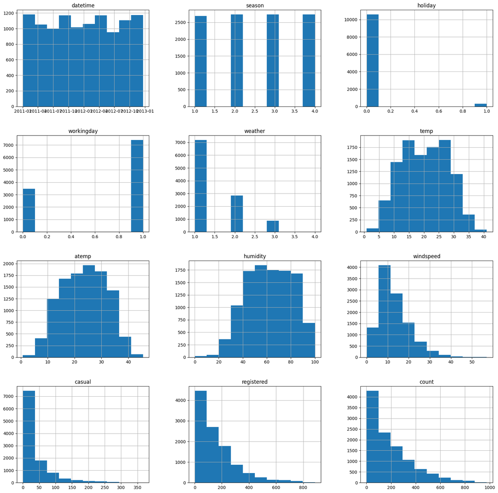

```python
# Create a histogram of all features to show the distribution of each one relative to the data. This is part of the exploritory data analysis
train.hist(figsize=(20, 20))
```

1. `datetime` Data is collected fairly consistently over time from 2011 to 2013.
2. `season` Quite uniform distribution across the four seasons.
3. `holiday` Holidays are infrequent.
4. `workingday` Most observations are working day, similar to previous feature.
5. `weather` The most frequent weather condition is presumably clear, few clouds. Mist, cloudy is also common. Light snow, rain less frequent. Heavy rain, ice pallets is extemely rare.
6. `temp` Roughly normal distribution. Most between 10°C to 30°C.
7. `atemp` Similar to temp. The peak is also 10-30°C range.
8. `humidity` Left-skewed distribution with peak around 40-90% humidity. The presense of 0% humidity data might suggest missing data or errors.
9. `windspeed` Right-skewed distribution with a large number of obervations having low wind speeds (0-20 km/h)
10. `count` Highly right-skewed. Very high rental counts are much rarer than lower counts.

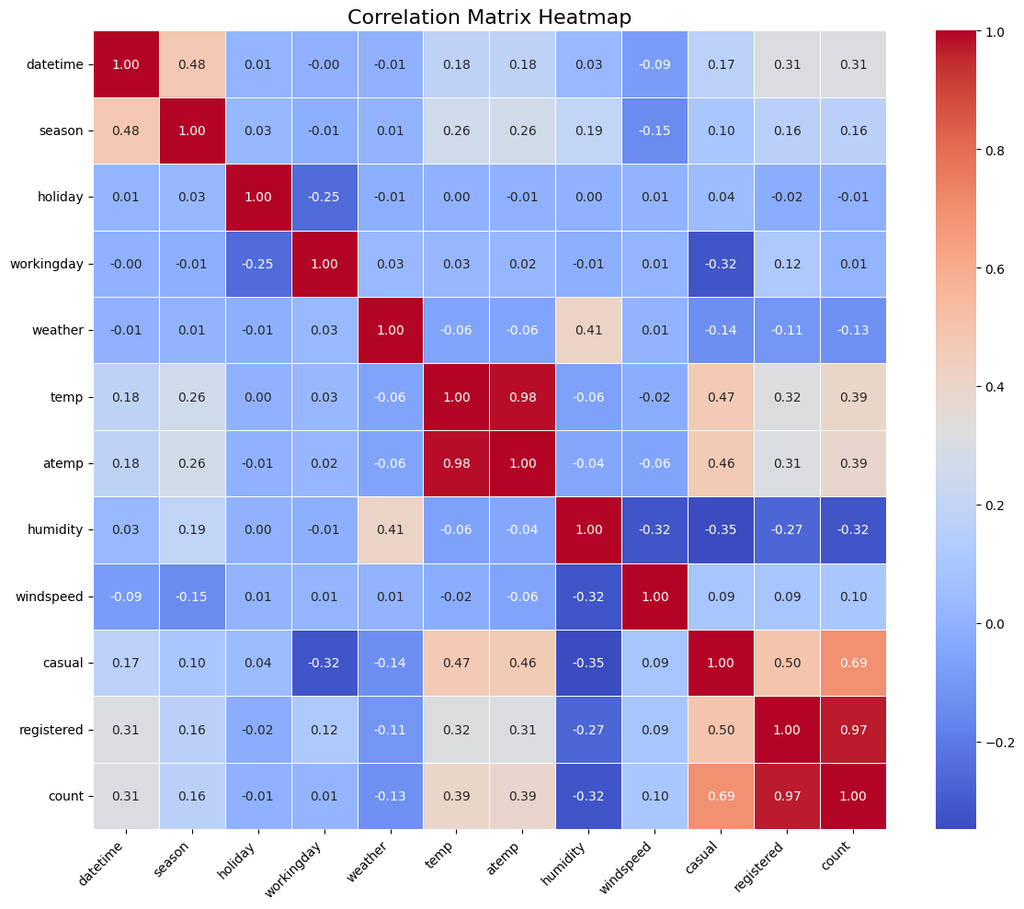

```python
import pandas as pd
import seaborn as sns
import matplotlib.pyplot as plt

correlation_matrix = train.corr()

plt.figure(figsize=(12, 10))
sns.heatmap(correlation_matrix, annot=True, cmap='coolwarm', fmt=".2f", linewidths=.5)
plt.title('Correlation Matrix Heatmap', fontsize=16)
plt.xticks(rotation=45, ha='right')
plt.yticks(rotation=0)
plt.tight_layout()
plt.show()
```

The count of bike rentals shows a strong positive correlation with both registered (0.97) and casual (0.69) users, and a moderate positive correlation with temp and atemp (0.39). Notably, temp and atemp are almost perfectly correlated. Furthermore, weather and humidity (0.41), and datetime and season (0.48) also exhibit expected moderate positive correlations. Other features generally show weaker linear relationships.

```python
train['datetime'].head()

# hourly basis variation.
```

|  | datetime |
| --- | --- |
| 0 | 2011-01-01 00:00:00 |
| 1 | 2011-01-01 01:00:00 |
| 2 | 2011-01-01 02:00:00 |
| 3 | 2011-01-01 03:00:00 |
| 4 | 2011-01-01 04:00:00 |

**dtype:** datetime64[ns]

```python
# create a new feature
train['year'] = train['datetime'].dt.year
train['month'] = train['datetime'].dt.month
train['dayofweek'] = train['datetime'].dt.dayofweek
train['hour'] = train['datetime'].dt.hour

train.head()
```

|  | datetime | season | holiday | workingday | weather | temp | atemp | humidity | windspeed | casual | registered | count | year | month | dayofweek | hour |
| --- | --- | --- | --- | --- | --- | --- | --- | --- | --- | --- | --- | --- | --- | --- | --- | --- |
| 0 | 2011-01-01 00:00:00 | 1 | 0 | 0 | 1 | 9.84 | 14.395 | 81 | 0.0 | 3 | 13 | 16 | 2011 | 1 | 5 | 0 |
| 1 | 2011-01-01 01:00:00 | 1 | 0 | 0 | 1 | 9.02 | 13.635 | 80 | 0.0 | 8 | 32 | 40 | 2011 | 1 | 5 | 1 |
| 2 | 2011-01-01 02:00:00 | 1 | 0 | 0 | 1 | 9.02 | 13.635 | 80 | 0.0 | 5 | 27 | 32 | 2011 | 1 | 5 | 2 |
| 3 | 2011-01-01 03:00:00 | 1 | 0 | 0 | 1 | 9.84 | 14.395 | 75 | 0.0 | 3 | 10 | 13 | 2011 | 1 | 5 | 3 |
| 4 | 2011-01-01 04:00:00 | 1 | 0 | 0 | 1 | 9.84 | 14.395 | 75 | 0.0 | 0 | 1 | 1 | 2011 | 1 | 5 | 4 |

```python
# create a new feature
test['year'] = test['datetime'].dt.year
test['month'] = test['datetime'].dt.month
test['dayofweek'] = test['datetime'].dt.dayofweek
test['hour'] = test['datetime'].dt.hour

test.head()
```

|  | datetime | season | holiday | workingday | weather | temp | atemp | humidity | windspeed | year | month | dayofweek | hour |
| --- | --- | --- | --- | --- | --- | --- | --- | --- | --- | --- | --- | --- | --- |
| 0 | 2011-01-20 00:00:00 | 1 | 0 | 1 | 1 | 10.66 | 11.365 | 56 | 26.0027 | 2011 | 1 | 3 | 0 |
| 1 | 2011-01-20 01:00:00 | 1 | 0 | 1 | 1 | 10.66 | 13.635 | 56 | 0.0000 | 2011 | 1 | 3 | 1 |
| 2 | 2011-01-20 02:00:00 | 1 | 0 | 1 | 1 | 10.66 | 13.635 | 56 | 0.0000 | 2011 | 1 | 3 | 2 |
| 3 | 2011-01-20 03:00:00 | 1 | 0 | 1 | 1 | 10.66 | 12.880 | 56 | 11.0014 | 2011 | 1 | 3 | 3 |
| 4 | 2011-01-20 04:00:00 | 1 | 0 | 1 | 1 | 10.66 | 12.880 | 56 | 11.0014 | 2011 | 1 | 3 | 4 |

```python
test_datetime_for_submission = test['datetime'].copy()
```

```python
train.drop(columns=['datetime'], axis=1, inplace=True)
test.drop(columns=['datetime'], axis=1, inplace=True)
```

## Make category types for these so models know they are not just numbers

- AutoGluon originally sees these as ints, but in reality they are int representations of a category.
- Setting the dtype to category will classify these as categories in AutoGluon.

```python
# train["season"] = train["season"].astype("category")
# train["weather"] = train["weather"].astype("category")
# test["season"] = test["season"].astype("category")
# test["weather"] = test["weather"].astype("category")
```

```python
# View are new featur
train.head()
```

|  | season | holiday | workingday | weather | temp | atemp | humidity | windspeed | casual | registered | count | year | month | dayofweek | hour |
| --- | --- | --- | --- | --- | --- | --- | --- | --- | --- | --- | --- | --- | --- | --- | --- |
| 0 | 1 | 0 | 0 | 1 | 9.84 | 14.395 | 81 | 0.0 | 3 | 13 | 16 | 2011 | 1 | 5 | 0 |
| 1 | 1 | 0 | 0 | 1 | 9.02 | 13.635 | 80 | 0.0 | 8 | 32 | 40 | 2011 | 1 | 5 | 1 |
| 2 | 1 | 0 | 0 | 1 | 9.02 | 13.635 | 80 | 0.0 | 5 | 27 | 32 | 2011 | 1 | 5 | 2 |
| 3 | 1 | 0 | 0 | 1 | 9.84 | 14.395 | 75 | 0.0 | 3 | 10 | 13 | 2011 | 1 | 5 | 3 |
| 4 | 1 | 0 | 0 | 1 | 9.84 | 14.395 | 75 | 0.0 | 0 | 1 | 1 | 2011 | 1 | 5 | 4 |

```
array([[<Axes: title={'center': 'season'}>,
        <Axes: title={'center': 'holiday'}>,
        <Axes: title={'center': 'workingday'}>,
        <Axes: title={'center': 'weather'}>],
       [<Axes: title={'center': 'temp'}>,
        <Axes: title={'center': 'atemp'}>,
        <Axes: title={'center': 'humidity'}>,
        <Axes: title={'center': 'windspeed'}>],
       [<Axes: title={'center': 'casual'}>,
        <Axes: title={'center': 'registered'}>,
        <Axes: title={'center': 'count'}>,
        <Axes: title={'center': 'year'}>],
       [<Axes: title={'center': 'month'}>,
        <Axes: title={'center': 'dayofweek'}>,
        <Axes: title={'center': 'hour'}>, <Axes: >]], dtype=object)
```

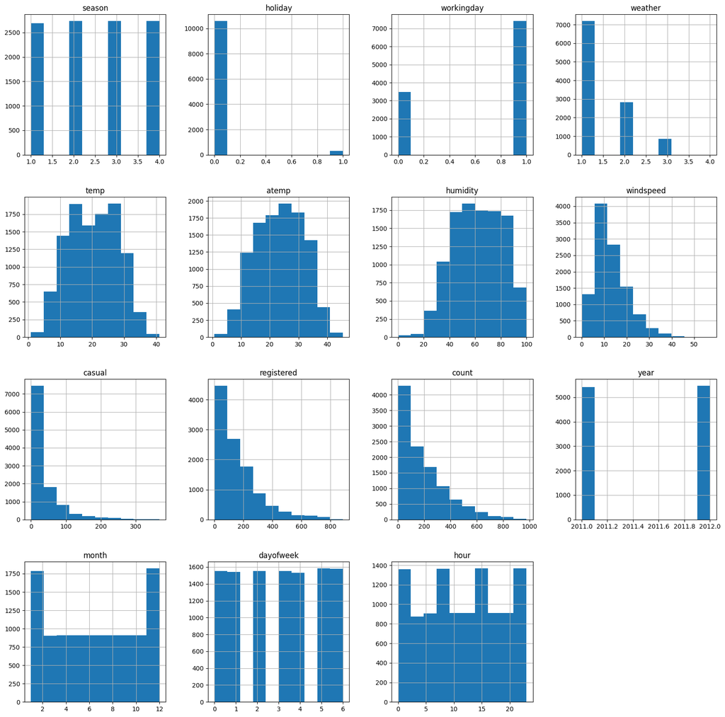

```python
# View histogram of all features again now with the hour feature
train.hist(figsize=(20, 20))
```

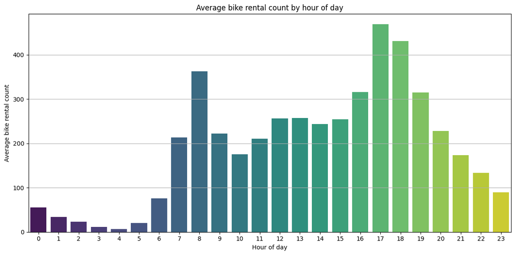

```python
hourly_avg_count = train.groupby('hour')['count'].mean().reset_index()

plt.figure(figsize=(12, 6))
sns.barplot(data=hourly_avg_count, x='hour', y='count', palette='viridis')
plt.title('Average bike rental count by hour of day')
plt.xlabel('Hour of day')
plt.ylabel('Average bike rental count')
plt.xticks(rotation=0)
plt.grid(axis='y')
plt.tight_layout()
plt.show()
```

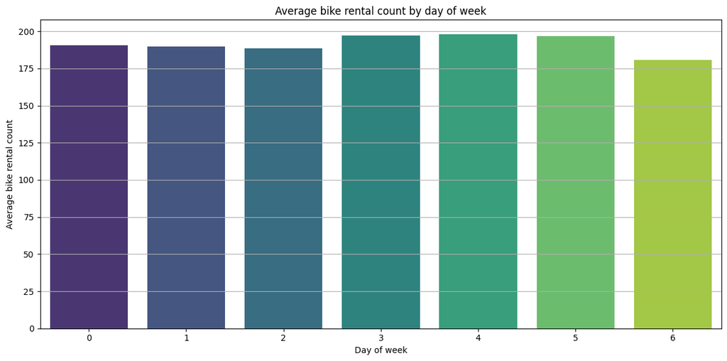

```python
daily_avg_count = train.groupby('dayofweek')['count'].mean().reset_index()

plt.figure(figsize=(12, 6))
sns.barplot(data=daily_avg_count, x='dayofweek', y='count', palette='viridis')
plt.title('Average bike rental count by day of week')
plt.xlabel('Day of week')
plt.ylabel('Average bike rental count')
plt.xticks(rotation=0)
plt.grid(axis='y')
plt.tight_layout()
plt.show()
# 0-6 - Monday to Sunday
```

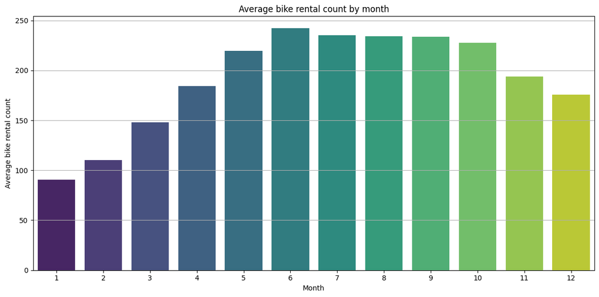

```python
month_avg_count = train.groupby('month')['count'].mean().reset_index()

plt.figure(figsize=(12, 6))
sns.barplot(data=month_avg_count, x='month', y='count', palette='viridis')
plt.title('Average bike rental count by month')
plt.xlabel('Month')
plt.ylabel('Average bike rental count')
plt.xticks(rotation=0)
plt.grid(axis='y')
plt.tight_layout()
plt.show()
```

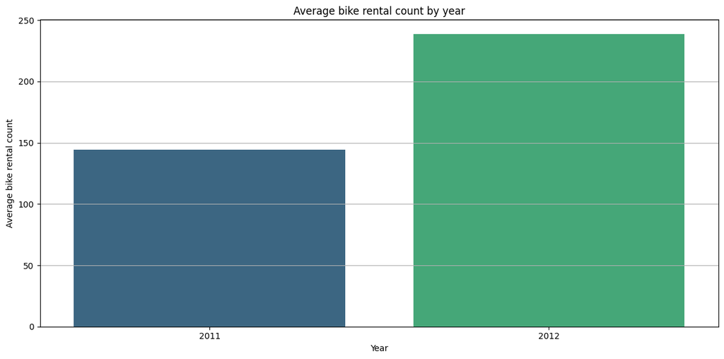

```python
year_avg_count = train.groupby('year')['count'].mean().reset_index()

plt.figure(figsize=(12, 6))
sns.barplot(data=year_avg_count, x='year', y='count', palette='viridis')
plt.title('Average bike rental count by year')
plt.xlabel('Year')
plt.ylabel('Average bike rental count')
plt.xticks(rotation=0)
plt.grid(axis='y')
plt.tight_layout()
plt.show()
```

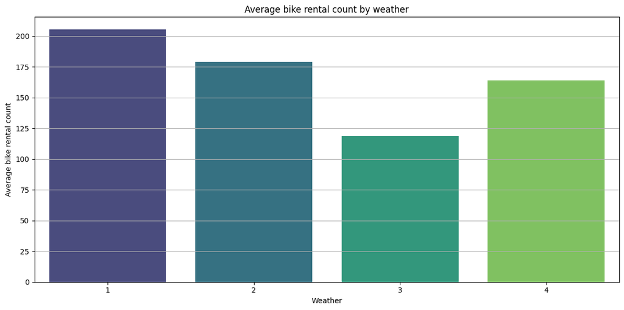

```python
weather_avg_count = train.groupby('weather')['count'].mean().reset_index()

plt.figure(figsize=(12, 6))
sns.barplot(data=weather_avg_count, x='weather', y='count', palette='viridis')
plt.title('Average bike rental count by weather')
plt.xlabel('Weather')
plt.ylabel('Average bike rental count')
plt.xticks(rotation=0)
plt.grid(axis='y')
plt.tight_layout()
plt.show()

# 1: Clear, Few clouds, Partly cloudy, Partly cloudy
# 2: Mist + Cloudy, Mist + Broken clouds, Mist + Few clouds, Mist
# 3: Light Snow, Light Rain + Thunderstorm + Scattered clouds, Light Rain + Scattered clouds
# 4: Heavy Rain + Ice Pallets + Thunderstorm + Mist, Snow + Fog
```

### New Feature Engineering

```python
def get_rush_hour(hour):
    if (6 <= hour <= 8) or (15 <= hour <=18): # High (7-9 AM & 4-7 PM)
        return 'high'
    elif 10 <= hour <= 14: # Moderate (10 AM - 3 PM)
        return 'mid'
    else: # Low (0-6 AM & 8 PM - 12 AM)
        return 'low'

train['activity_level'] = train['hour'].apply(get_rush_hour)
test['activity_level'] = test['hour'].apply(get_rush_hour)
```

```python
train.head()
```

|  | season | holiday | workingday | weather | temp | atemp | humidity | windspeed | casual | registered | count | year | month | dayofweek | hour | activity_level |
| --- | --- | --- | --- | --- | --- | --- | --- | --- | --- | --- | --- | --- | --- | --- | --- | --- |
| 0 | 1 | 0 | 0 | 1 | 9.84 | 14.395 | 81 | 0.0 | 3 | 13 | 16 | 2011 | 1 | 5 | 0 | low |
| 1 | 1 | 0 | 0 | 1 | 9.02 | 13.635 | 80 | 0.0 | 8 | 32 | 40 | 2011 | 1 | 5 | 1 | low |
| 2 | 1 | 0 | 0 | 1 | 9.02 | 13.635 | 80 | 0.0 | 5 | 27 | 32 | 2011 | 1 | 5 | 2 | low |
| 3 | 1 | 0 | 0 | 1 | 9.84 | 14.395 | 75 | 0.0 | 3 | 10 | 13 | 2011 | 1 | 5 | 3 | low |
| 4 | 1 | 0 | 0 | 1 | 9.84 | 14.395 | 75 | 0.0 | 0 | 1 | 1 | 2011 | 1 | 5 | 4 | low |

```python
test.head()
```

|  | season | holiday | workingday | weather | temp | atemp | humidity | windspeed | year | month | dayofweek | hour | activity_level |
| --- | --- | --- | --- | --- | --- | --- | --- | --- | --- | --- | --- | --- | --- |
| 0 | 1 | 0 | 1 | 1 | 10.66 | 11.365 | 56 | 26.0027 | 2011 | 1 | 3 | 0 | low |
| 1 | 1 | 0 | 1 | 1 | 10.66 | 13.635 | 56 | 0.0000 | 2011 | 1 | 3 | 1 | low |
| 2 | 1 | 0 | 1 | 1 | 10.66 | 13.635 | 56 | 0.0000 | 2011 | 1 | 3 | 2 | low |
| 3 | 1 | 0 | 1 | 1 | 10.66 | 12.880 | 56 | 11.0014 | 2011 | 1 | 3 | 3 | low |
| 4 | 1 | 0 | 1 | 1 | 10.66 | 12.880 | 56 | 11.0014 | 2011 | 1 | 3 | 4 | low |

```python
bins_temp = [-float('inf'), 10, 25, float('inf')]
labels_temp = ['cold', 'mild', 'hot']
train['temp_category'] = pd.cut(train['temp'], bins=bins_temp, labels=labels_temp, right=False)
test['temp_category'] = pd.cut(test['temp'], bins=bins_temp, labels=labels_temp, right=False)
```

```python
train.head()
```

|  | season | holiday | workingday | weather | temp | atemp | humidity | windspeed | casual | registered | count | year | month | dayofweek | hour | activity_level | temp_category |
| --- | --- | --- | --- | --- | --- | --- | --- | --- | --- | --- | --- | --- | --- | --- | --- | --- | --- |
| 0 | 1 | 0 | 0 | 1 | 9.84 | 14.395 | 81 | 0.0 | 3 | 13 | 16 | 2011 | 1 | 5 | 0 | low | cold |
| 1 | 1 | 0 | 0 | 1 | 9.02 | 13.635 | 80 | 0.0 | 8 | 32 | 40 | 2011 | 1 | 5 | 1 | low | cold |
| 2 | 1 | 0 | 0 | 1 | 9.02 | 13.635 | 80 | 0.0 | 5 | 27 | 32 | 2011 | 1 | 5 | 2 | low | cold |
| 3 | 1 | 0 | 0 | 1 | 9.84 | 14.395 | 75 | 0.0 | 3 | 10 | 13 | 2011 | 1 | 5 | 3 | low | cold |
| 4 | 1 | 0 | 0 | 1 | 9.84 | 14.395 | 75 | 0.0 | 0 | 1 | 1 | 2011 | 1 | 5 | 4 | low | cold |

#### Identify all columns to be One-Hot Encoded and convert to 'category' dtype

```python
categorical_cols_for_ohe = [
    'season', 'weather', 'year', 'month', 'dayofweek', 'hour',
    'activity_level', 'temp_category'
]
```

```python
for col in categorical_cols_for_ohe:
    train[col] = train[col].astype('category')
    test[col] = test[col].astype('category')
```

#### One-Hot Encoding for Train and Test Sets

```python
train_labels = train['count']
train_no_count = train.drop(columns=['count'])

combined = pd.concat([train_no_count, test], ignore_index=True)

combined_encoded = pd.get_dummies(combined, columns=categorical_cols_for_ohe, drop_first=False)

train_encod = combined_encoded.iloc[:len(train_no_count)].copy()
test_encod = combined_encoded.iloc[len(train_no_count):].copy()

train_encod['count'] = train_labels.values
```

```python
train_encod.head()
```

|  | holiday | workingday | temp | atemp | humidity | windspeed | casual | registered | season_1 | season_2 | ... | hour_21 | hour_22 | hour_23 | activity_level_high | activity_level_low | activity_level_mid | temp_category_cold | temp_category_mild | temp_category_hot | count |
| --- | --- | --- | --- | --- | --- | --- | --- | --- | --- | --- | --- | --- | --- | --- | --- | --- | --- | --- | --- | --- | --- |
| 0 | 0 | 0 | 9.84 | 14.395 | 81 | 0.0 | 3.0 | 13.0 | True | False | ... | False | False | False | False | True | False | True | False | False | 16 |
| 1 | 0 | 0 | 9.02 | 13.635 | 80 | 0.0 | 8.0 | 32.0 | True | False | ... | False | False | False | False | True | False | True | False | False | 40 |
| 2 | 0 | 0 | 9.02 | 13.635 | 80 | 0.0 | 5.0 | 27.0 | True | False | ... | False | False | False | False | True | False | True | False | False | 32 |
| 3 | 0 | 0 | 9.84 | 14.395 | 75 | 0.0 | 3.0 | 10.0 | True | False | ... | False | False | False | False | True | False | True | False | False | 13 |
| 4 | 0 | 0 | 9.84 | 14.395 | 75 | 0.0 | 0.0 | 1.0 | True | False | ... | False | False | False | False | True | False | True | False | False | 1 |

```python
print(train_encod.shape)
print(test_encod.shape)
print(train.shape)
print(test.shape)
```

[output not shown]

```python
train_encod.drop(columns=['casual', 'registered', 'temp'], axis=1, inplace=True)
test_encod.drop(columns=['casual', 'registered', 'temp'], axis=1, inplace=True)
```

```python
train_encod.info()
```

```
<class 'pandas.core.frame.DataFrame'>
RangeIndex: 10886 entries, 0 to 10885
Data columns (total 65 columns):
 #   Column               Non-Null Count  Dtype
---  ------               --------------  -----
 0   holiday              10886 non-null  int64
 1   workingday           10886 non-null  int64
 2   atemp                10886 non-null  float64
 3   humidity             10886 non-null  int64
 4   windspeed            10886 non-null  float64
 5   season_1             10886 non-null  bool
 6   season_2             10886 non-null  bool
 7   season_3             10886 non-null  bool
 8   season_4             10886 non-null  bool
 9   weather_1            10886 non-null  bool
```

[output cut: 57 more lines]

```python
test_encod.info()
```

```
<class 'pandas.core.frame.DataFrame'>
RangeIndex: 6493 entries, 10886 to 17378
Data columns (total 64 columns):
 #   Column               Non-Null Count  Dtype
---  ------               --------------  -----
 0   holiday              6493 non-null   int64
 1   workingday           6493 non-null   int64
 2   atemp                6493 non-null   float64
 3   humidity             6493 non-null   int64
 4   windspeed            6493 non-null   float64
 5   season_1             6493 non-null   bool
 6   season_2             6493 non-null   bool
 7   season_3             6493 non-null   bool
 8   season_4             6493 non-null   bool
 9   weather_1            6493 non-null   bool
```

[output cut: 56 more lines]

## Step 5: Rerun the model with the same settings as before, just with more features

```python
label='count'
train_data = train_encod
eval_metric = 'root_mean_squared_error'
```

```python
predictor_new_features = TabularPredictor(label=label, eval_metric=eval_metric).fit(
    train_data=train_data,
    time_limit=600,
    presets='best_quality'
)
```

```
No path specified. Models will be saved in: "AutogluonModels/ag-20250608_163616"
Verbosity: 2 (Standard Logging)
=================== System Info ===================
AutoGluon Version:  1.3.1
Python Version:     3.11.13
Operating System:   Linux
Platform Machine:   x86_64
Platform Version:   #1 SMP PREEMPT_DYNAMIC Sun Mar 30 16:01:29 UTC 2025
CPU Count:          2
Memory Avail:       10.07 GB / 12.67 GB (79.4%)
Disk Space Avail:   63.27 GB / 107.72 GB (58.7%)
===================================================
Presets specified: ['best_quality']
Setting dynamic_stacking from 'auto' to True. Reason: Enable dynamic_stacking when use_bag_holdout is disabled. (use_bag_holdout=False)
Stack configuration (auto_stack=True): num_stack_levels=1, num_bag_folds=8, num_bag_sets=1
DyStack is enabled (dynamic_stacking=True). AutoGluon will try to determine whether the input data is affected by stacked overfitting and enable or disable stacking as a consequence.
	This is used to identify the optimal `num_stack_levels` value. Copies of AutoGluon will be fit on subsets of the data. Then holdout validation data is used to detect stacked overfitting.
	Running DyStack for up to 150s of the 600s of remaining time (25%).
		Context path: "/content/AutogluonModels/ag-20250608_163616/ds_sub_fit/sub_fit_ho"
Leaderboard on holdout data (DyStack):
                   model  score_holdout   score_val              eval_metric  pred_time_test  pred_time_val    fit_time  pred_time_test_marginal  pred_time_val_marginal  fit_time_marginal  stack_level  can_infer  fit_order
0      LightGBMXT_BAG_L2     -34.718157  -39.307961  root_mean_squared_error       11.581091       8.143822  154.921463                 0.275527                0.433913          34.616565            2       True          6
1    WeightedEnsemble_L3     -35.167882  -37.650282  root_mean_squared_error       11.583792       8.144634  154.945983                 0.002701                0.000812           0.024520            3       True          7
2      LightGBMXT_BAG_L1     -35.277871  -37.786354  root_mean_squared_error        9.026001       3.619980   62.639772                 9.026001                3.619980          62.639772            1       True          3
3    WeightedEnsemble_L2     -35.331038  -37.658716  root_mean_squared_error       11.210753       7.607419  120.306693                 0.002572                0.000927           0.023274            2       True          5
4        LightGBM_BAG_L1     -37.074019  -39.783747  root_mean_squared_error        2.182180       3.986513   57.643646                 2.182180                3.986513          57.643646            1       True          4
5  KNeighborsUnif_BAG_L1    -165.147355 -165.471994  root_mean_squared_error        0.031638       0.054100    0.012120                 0.031638                0.054100           0.012120            1       True          1
6  KNeighborsDist_BAG_L1    -184.206727 -178.080657  root_mean_squared_error        0.065745       0.049316    0.009359                 0.065745                0.049316           0.009359            1       True          2
	1	 = Optimal   num_stack_levels (Stacked Overfitting Occurred: False)
	193s	 = DyStack   runtime |	407s	 = Remaining runtime
Starting main fit with num_stack_levels=1.
	For future fit calls on this dataset, you can skip DyStack to save time: `predictor.fit(..., dynamic_stacking=False, num_stack_levels=1)`
Beginning AutoGluon training ... Time limit = 407s
AutoGluon will save models to "/content/AutogluonModels/ag-20250608_163616"
Train Data Rows:    10886
Train Data Columns: 64
Label Column:       count
Problem Type:       regression
Preprocessing data ...
Using Feature Generators to preprocess the data ...
```

[output cut: 87 more lines]

```
	Fitting 8 child models (S1F1 - S1F8) | Fitting with ParallelLocalFoldFittingStrategy (2 workers, per: cpus=1, gpus=0, memory=0.24%)
	-36.4397	 = Validation score   (-root_mean_squared_error)
	33.91s	 = Training   runtime
	0.18s	 = Validation runtime
Fitting model: RandomForestMSE_BAG_L2 ... Training model for up to 30.05s of the 30.03s of remaining time.
	-36.8797	 = Validation score   (-root_mean_squared_error)
	67.11s	 = Training   runtime
	0.97s	 = Validation runtime
Fitting model: WeightedEnsemble_L3 ... Training model for up to 360.00s of the -38.91s of remaining time.
	Ensemble Weights: {'LightGBM_BAG_L2': 0.312, 'LightGBMXT_BAG_L1': 0.25, 'RandomForestMSE_BAG_L2': 0.188, 'CatBoost_BAG_L1': 0.125, 'ExtraTreesMSE_BAG_L1': 0.062, 'LightGBMXT_BAG_L2': 0.062}
	-36.0256	 = Validation score   (-root_mean_squared_error)
	0.03s	 = Training   runtime
	0.0s	 = Validation runtime
AutoGluon training complete, total runtime = 446.27s ... Best model: WeightedEnsemble_L3 | Estimated inference throughput: 90.6 rows/s (1361 batch size)
TabularPredictor saved. To load, use: predictor = TabularPredictor.load("/content/AutogluonModels/ag-20250608_163616")
```

```python
predictor_new_features.fit_summary()
```

```
*** Summary of fit() ***
Estimated performance of each model:
                     model   score_val              eval_metric  pred_time_val    fit_time  pred_time_val_marginal  fit_time_marginal  stack_level  can_infer  fit_order
0      WeightedEnsemble_L3  -36.025632  root_mean_squared_error      17.392621  414.487999                0.000616           0.030170            3       True         12
1      WeightedEnsemble_L2  -36.342294  root_mean_squared_error      15.199467  276.481021                0.000665           0.023896            2       True          8
2          LightGBM_BAG_L2  -36.439743  root_mean_squared_error      15.538007  310.418217                0.179702          33.913606            2       True         10
3   RandomForestMSE_BAG_L2  -36.879714  root_mean_squared_error      16.326466  343.616099                0.968162          67.111487            2       True         11
4        LightGBMXT_BAG_L1  -37.194791  root_mean_squared_error       7.615102   60.279541                7.615102          60.279541            1       True          3
5        LightGBMXT_BAG_L2  -37.245221  root_mean_squared_error      16.244141  313.432736                0.885836          36.928124            2       True          9
6          CatBoost_BAG_L1  -37.997072  root_mean_squared_error       0.465527   91.085938                0.465527          91.085938            1       True          6
7          LightGBM_BAG_L1  -38.647426  root_mean_squared_error       5.545916   60.726763                5.545916          60.726763            1       True          4
8     ExtraTreesMSE_BAG_L1  -42.254943  root_mean_squared_error       0.779443   24.700765                0.779443          24.700765            1       True          7
9   RandomForestMSE_BAG_L1  -42.418907  root_mean_squared_error       0.792815   39.664118                0.792815          39.664118            1       True          5
10   KNeighborsUnif_BAG_L1 -165.034593  root_mean_squared_error       0.067019    0.023621                0.067019           0.023621            1       True          1
11   KNeighborsDist_BAG_L1 -178.534166  root_mean_squared_error       0.092483    0.023865                0.092483           0.023865            1       True          2
Number of models trained: 12
Types of models trained:
{'StackerEnsembleModel_CatBoost', 'WeightedEnsembleModel', 'StackerEnsembleModel_RF', 'StackerEnsembleModel_LGB', 'StackerEnsembleModel_XT', 'StackerEnsembleModel_KNN'}
Bagging used: True  (with 8 folds)
Multi-layer stack-ensembling used: True  (with 3 levels)
Feature Metadata (Processed):
(raw dtype, special dtypes):
('float', [])     :  2 | ['atemp', 'windspeed']
('int', [])       :  1 | ['humidity']
('int', ['bool']) : 61 | ['holiday', 'workingday', 'season_1', 'season_2', 'season_3', ...]
Plot summary of models saved to file: /content/AutogluonModels/ag-20250608_163616/SummaryOfModels.html
*** End of fit() summary ***
```

```
{'model_types': {'KNeighborsUnif_BAG_L1': 'StackerEnsembleModel_KNN',
  'KNeighborsDist_BAG_L1': 'StackerEnsembleModel_KNN',
  'LightGBMXT_BAG_L1': 'StackerEnsembleModel_LGB',
  'LightGBM_BAG_L1': 'StackerEnsembleModel_LGB',
  'RandomForestMSE_BAG_L1': 'StackerEnsembleModel_RF',
  'CatBoost_BAG_L1': 'StackerEnsembleModel_CatBoost',
  'ExtraTreesMSE_BAG_L1': 'StackerEnsembleModel_XT',
  'WeightedEnsemble_L2': 'WeightedEnsembleModel',
  'LightGBMXT_BAG_L2': 'StackerEnsembleModel_LGB',
  'LightGBM_BAG_L2': 'StackerEnsembleModel_LGB',
  'RandomForestMSE_BAG_L2': 'StackerEnsembleModel_RF',
  'WeightedEnsemble_L3': 'WeightedEnsembleModel'},
 'model_performance': {'KNeighborsUnif_BAG_L1': np.float64(-165.03459343853473),
  'KNeighborsDist_BAG_L1': np.float64(-178.53416647768907),
  'LightGBMXT_BAG_L1': np.float64(-37.19479069800905),
  'LightGBM_BAG_L1': np.float64(-38.64742592474607),
  'RandomForestMSE_BAG_L1': np.float64(-42.41890681898908),
  'CatBoost_BAG_L1': np.float64(-37.997072377630744),
  'ExtraTreesMSE_BAG_L1': np.float64(-42.254943202685425),
  'WeightedEnsemble_L2': np.float64(-36.34229421709832),
  'LightGBMXT_BAG_L2': np.float64(-37.24522144374951),
  'LightGBM_BAG_L2': np.float64(-36.439743337335536),
  'RandomForestMSE_BAG_L2': np.float64(-36.87971427076179),
  'WeightedEnsemble_L3': np.float64(-36.02563225856243)},
 'model_best': 'WeightedEnsemble_L3',
 'model_paths': {'KNeighborsUnif_BAG_L1': ['KNeighborsUnif_BAG_L1'],
  'KNeighborsDist_BAG_L1': ['KNeighborsDist_BAG_L1'],
  'LightGBMXT_BAG_L1': ['LightGBMXT_BAG_L1'],
  'LightGBM_BAG_L1': ['LightGBM_BAG_L1'],
  'RandomForestMSE_BAG_L1': ['RandomForestMSE_BAG_L1'],
  'CatBoost_BAG_L1': ['CatBoost_BAG_L1'],
  'ExtraTreesMSE_BAG_L1': ['ExtraTreesMSE_BAG_L1'],
  'WeightedEnsemble_L2': ['WeightedEnsemble_L2'],
  'LightGBMXT_BAG_L2': ['LightGBMXT_BAG_L2'],
  'LightGBM_BAG_L2': ['LightGBM_BAG_L2'],
  'RandomForestMSE_BAG_L2': ['RandomForestMSE_BAG_L2'],
  'WeightedEnsemble_L3': ['WeightedEnsemble_L3']},
 'model_fit_times': {'KNeighborsUnif_BAG_L1': 0.0236208438873291,
  'KNeighborsDist_BAG_L1': 0.0238649845123291,
  'LightGBMXT_BAG_L1': 60.279541015625,
```

[output cut: 150 more lines]

```
 11       0.092483    0.023865                0.092483           0.023865

     stack_level  can_infer  fit_order
 0             3       True         12
 1             2       True          8
 2             2       True         10
 3             2       True         11
 4             1       True          3
 5             2       True          9
 6             1       True          6
 7             1       True          4
 8             1       True          7
 9             1       True          5
 10            1       True          1
 11            1       True          2  }
```

```python
leaderboard_new_features_df = pd.DataFrame(predictor_new_features.leaderboard(silent=True))
leaderboard_new_features_df
```

|  | model | score_val | eval_metric | pred_time_val | fit_time | pred_time_val_marginal | fit_time_marginal | stack_level | can_infer | fit_order |
| --- | --- | --- | --- | --- | --- | --- | --- | --- | --- | --- |
| 0 | WeightedEnsemble_L3 | -36.025632 | root_mean_squared_error | 17.392621 | 414.487999 | 0.000616 | 0.030170 | 3 | True | 12 |
| 1 | WeightedEnsemble_L2 | -36.342294 | root_mean_squared_error | 15.199467 | 276.481021 | 0.000665 | 0.023896 | 2 | True | 8 |
| 2 | LightGBM_BAG_L2 | -36.439743 | root_mean_squared_error | 15.538007 | 310.418217 | 0.179702 | 33.913606 | 2 | True | 10 |
| 3 | RandomForestMSE_BAG_L2 | -36.879714 | root_mean_squared_error | 16.326466 | 343.616099 | 0.968162 | 67.111487 | 2 | True | 11 |
| 4 | LightGBMXT_BAG_L1 | -37.194791 | root_mean_squared_error | 7.615102 | 60.279541 | 7.615102 | 60.279541 | 1 | True | 3 |
| 5 | LightGBMXT_BAG_L2 | -37.245221 | root_mean_squared_error | 16.244141 | 313.432736 | 0.885836 | 36.928124 | 2 | True | 9 |
| 6 | CatBoost_BAG_L1 | -37.997072 | root_mean_squared_error | 0.465527 | 91.085938 | 0.465527 | 91.085938 | 1 | True | 6 |
| 7 | LightGBM_BAG_L1 | -38.647426 | root_mean_squared_error | 5.545916 | 60.726763 | 5.545916 | 60.726763 | 1 | True | 4 |
| 8 | ExtraTreesMSE_BAG_L1 | -42.254943 | root_mean_squared_error | 0.779443 | 24.700765 | 0.779443 | 24.700765 | 1 | True | 7 |
| 9 | RandomForestMSE_BAG_L1 | -42.418907 | root_mean_squared_error | 0.792815 | 39.664118 | 0.792815 | 39.664118 | 1 | True | 5 |
| 10 | KNeighborsUnif_BAG_L1 | -165.034593 | root_mean_squared_error | 0.067019 | 0.023621 | 0.067019 | 0.023621 | 1 | True | 1 |
| 11 | KNeighborsDist_BAG_L1 | -178.534166 | root_mean_squared_error | 0.092483 | 0.023865 | 0.092483 | 0.023865 | 1 | True | 2 |

```python
predictor_new_features.model_hyperparameters('CatBoost_BAG_L1')
```

```
{}
```

```python
test_encod = test_encod.reset_index(drop=True)
```

```python
predictions_new_features = predictor_new_features.predict(test_encod)
predictions_new_features.head()
```

|  | count |
| --- | --- |
| 0 | 12.473785 |
| 1 | 5.303522 |
| 2 | 4.675133 |
| 3 | 4.077533 |
| 4 | 4.340981 |

**dtype:** float32

```python
predictions_new_features.describe()
```

|  | count |
| --- | --- |
| count | 6493.000000 |
| mean | 189.420822 |
| std | 175.947495 |
| min | 0.000000 |
| 25% | 44.769012 |
| 50% | 145.153229 |
| 75% | 281.498230 |
| max | 912.719543 |

**dtype:** float64

```python
# How many negative values do we have?
(predictions_new_features < 0).sum()
# Set them to zero
predictions_new_features[predictions_new_features < 0] = 0
```

```python
# Same submitting predictions
submission_new_features = pd.read_csv("sampleSubmission.csv", parse_dates=['datetime'])
submission_new_features["count"] = predictions_new_features
submission_new_features.to_csv("submission_new_features.csv", index=False)
```

```python
submission_new_features.head()
```

|  | datetime | count |
| --- | --- | --- |
| 0 | 2011-01-20 00:00:00 | 12.473785 |
| 1 | 2011-01-20 01:00:00 | 5.303522 |
| 2 | 2011-01-20 02:00:00 | 4.675133 |
| 3 | 2011-01-20 03:00:00 | 4.077533 |
| 4 | 2011-01-20 04:00:00 | 4.340981 |

```python
!kaggle competitions submit -c bike-sharing-demand -f submission_new_features.csv -m "new features"
```

```
100% 188k/188k [00:01<00:00, 184kB/s]
Successfully submitted to Bike Sharing Demand
```

```python
!kaggle competitions submissions -c bike-sharing-demand | tail -n +1 | head -n 6
```

```
fileName                     date                        description                          status                     publicScore  privateScore
---------------------------  --------------------------  -----------------------------------  -------------------------  -----------  ------------
submission_new_features.csv  2025-06-08 17:23:33.220000  new features                         SubmissionStatus.COMPLETE  0.46654      0.46654
submission.csv               2025-06-08 16:36:07.093000  first raw submission                 SubmissionStatus.COMPLETE  1.80714      1.80714
submission_new_hpo3.csv      2025-06-07 22:19:23.107000  new features with hyperparameters 3  SubmissionStatus.COMPLETE  0.47284      0.47284
submission_new_hpo2.csv      2025-06-07 22:07:04.210000  new features with hyperparameters 2  SubmissionStatus.COMPLETE  0.47384      0.47384
```

#### New Score of `0.46654`

## Step 6: Hyper parameter optimization

- There are many options for hyper parameter optimization.
- Options are to change the AutoGluon higher level parameters or the individual model hyperparameters.
- The hyperparameters of the models themselves that are in AutoGluon. Those need the `hyperparameter` and `hyperparameter_tune_kwargs` arguments.

```python
from autogluon.common import space

# Only LightGBM
hyperparameters = {
    'GBM': [{
        # 'ag_args': {'name_suffix': 'LightGBM', 'model_type': 'GBM'},
        'learning_rate': space.Real(0.01, 0.1, default=0.03, log=True),
        'num_leaves': space.Int(32, 128, default=64),
        'min_data_in_leaf': space.Int(3, 20, default=5),
        'extra_trees': True
    }]
}

hyperparameter_tune_kwargs = {
    'num_trials': 10,
    'scheduler': 'local',
    'searcher': 'auto',
}
```

```python
label='count'
train_data = train_encod
eval_metric = 'root_mean_squared_error'
```

```python
predictor_new_hpo = TabularPredictor(label=label, problem_type='regression').fit(
    train_data=train_data,
    presets='high_quality',
    time_limit=600,
    hyperparameters=hyperparameters,
    hyperparameter_tune_kwargs=hyperparameter_tune_kwargs,
    refit_full='best'
)
```

```
No path specified. Models will be saved in: "AutogluonModels/ag-20250608_172445"
Verbosity: 2 (Standard Logging)
=================== System Info ===================
AutoGluon Version:  1.3.1
Python Version:     3.11.13
Operating System:   Linux
Platform Machine:   x86_64
Platform Version:   #1 SMP PREEMPT_DYNAMIC Sun Mar 30 16:01:29 UTC 2025
CPU Count:          2
Memory Avail:       9.92 GB / 12.67 GB (78.3%)
Disk Space Avail:   62.36 GB / 107.72 GB (57.9%)
===================================================
Presets specified: ['high_quality']
Warning: hyperparameter tuning is currently experimental and may cause the process to hang.
Setting dynamic_stacking from 'auto' to True. Reason: Enable dynamic_stacking when use_bag_holdout is disabled. (use_bag_holdout=False)
Stack configuration (auto_stack=True): num_stack_levels=1, num_bag_folds=8, num_bag_sets=1
Note: `save_bag_folds=False`! This will greatly reduce peak disk usage during fit (by ~8x), but runs the risk of an out-of-memory error during model refit if memory is small relative to the data size.
	You can avoid this risk by setting `save_bag_folds=True`.
DyStack is enabled (dynamic_stacking=True). AutoGluon will try to determine whether the input data is affected by stacked overfitting and enable or disable stacking as a consequence.
	This is used to identify the optimal `num_stack_levels` value. Copies of AutoGluon will be fit on subsets of the data. Then holdout validation data is used to detect stacked overfitting.
	Running DyStack for up to 150s of the 600s of remaining time (25%).
		Context path: "/content/AutogluonModels/ag-20250608_172445/ds_sub_fit/sub_fit_ho"
Leaderboard on holdout data (DyStack):
                      model  score_holdout  score_val              eval_metric  pred_time_test pred_time_val  fit_time  pred_time_test_marginal pred_time_val_marginal  fit_time_marginal  stack_level  can_infer  fit_order
0   LightGBM_BAG_L2/T1_FULL     -33.948174 -39.196300  root_mean_squared_error        0.451779          None  8.178266                 0.060044                   None           0.859636            2       True          2
1  WeightedEnsemble_L3_FULL     -35.201084 -37.802535  root_mean_squared_error        0.454383          None  8.209712                 0.002604                   None           0.031446            3       True          3
2   LightGBM_BAG_L1/T1_FULL     -35.441827 -37.815677  root_mean_squared_error        0.391735          None  7.318630                 0.391735                   None           7.318630            1       True          1
	1	 = Optimal   num_stack_levels (Stacked Overfitting Occurred: False)
	126s	 = DyStack   runtime |	474s	 = Remaining runtime
Starting main fit with num_stack_levels=1.
	For future fit calls on this dataset, you can skip DyStack to save time: `predictor.fit(..., dynamic_stacking=False, num_stack_levels=1)`
Beginning AutoGluon training ... Time limit = 474s
AutoGluon will save models to "/content/AutogluonModels/ag-20250608_172445"
Train Data Rows:    10886
Train Data Columns: 64
Label Column:       count
Problem Type:       regression
Preprocessing data ...
Using Feature Generators to preprocess the data ...
Fitting AutoMLPipelineFeatureGenerator...
```

[output cut: 21 more lines]

```
		('int', ['bool']) : 61 | ['holiday', 'workingday', 'season_1', 'season_2', 'season_3', ...]
	0.8s = Fit runtime
	64 features in original data used to generate 64 features in processed data.
	Train Data (Processed) Memory Usage: 0.88 MB (0.0% of available memory)
Data preprocessing and feature engineering runtime = 0.8s ...
AutoGluon will gauge predictive performance using evaluation metric: 'root_mean_squared_error'
	This metric's sign has been flipped to adhere to being higher_is_better. The metric score can be multiplied by -1 to get the metric value.
	To change this, specify the eval_metric parameter of Predictor()
User-specified model hyperparameters to be fit:
{
	'GBM': [{'learning_rate': Real: lower=0.01, upper=0.1, 'num_leaves': Int: lower=32, upper=128, 'min_data_in_leaf': Int: lower=3, upper=20, 'extra_trees': True}],
}
AutoGluon will fit 2 stack levels (L1 to L2) ...
Fitting 1 L1 models, fit_strategy="sequential" ...
Hyperparameter tuning model: LightGBM_BAG_L1 ... Tuning model for up to 283.77s of the 473.07s of remaining time.
```

```
	Fitting 8 child models (S1F1 - S1F8) | Fitting with ParallelLocalFoldFittingStrategy (2 workers, per: cpus=1, gpus=0, memory=0.36%)
	Fitting 8 child models (S1F1 - S1F8) | Fitting with ParallelLocalFoldFittingStrategy (2 workers, per: cpus=1, gpus=0, memory=0.53%)
	Fitting 8 child models (S1F1 - S1F8) | Fitting with ParallelLocalFoldFittingStrategy (2 workers, per: cpus=1, gpus=0, memory=0.63%)
	Fitting 8 child models (S1F1 - S1F8) | Fitting with ParallelLocalFoldFittingStrategy (2 workers, per: cpus=1, gpus=0, memory=0.39%)
	Fitting 8 child models (S1F1 - S1F8) | Fitting with ParallelLocalFoldFittingStrategy (2 workers, per: cpus=1, gpus=0, memory=0.33%)
	Stopping HPO to satisfy time limit...
Fitted model: LightGBM_BAG_L1/T1 ...
	-36.9601	 = Validation score   (-root_mean_squared_error)
	63.08s	 = Training   runtime
	5.55s	 = Validation runtime
Fitted model: LightGBM_BAG_L1/T2 ...
	-36.8143	 = Validation score   (-root_mean_squared_error)
	53.13s	 = Training   runtime
	2.35s	 = Validation runtime
Fitted model: LightGBM_BAG_L1/T3 ...
	-36.9674	 = Validation score   (-root_mean_squared_error)
	56.0s	 = Training   runtime
	2.73s	 = Validation runtime
Fitted model: LightGBM_BAG_L1/T4 ...
	-37.667	 = Validation score   (-root_mean_squared_error)
	44.59s	 = Training   runtime
	1.28s	 = Validation runtime
Fitted model: LightGBM_BAG_L1/T5 ...
	-36.7476	 = Validation score   (-root_mean_squared_error)
	60.22s	 = Training   runtime
	5.47s	 = Validation runtime
Fitting model: WeightedEnsemble_L2 ... Training model for up to 360.00s of the 195.80s of remaining time.
	Ensemble Weights: {'LightGBM_BAG_L1/T5': 0.36, 'LightGBM_BAG_L1/T2': 0.28, 'LightGBM_BAG_L1/T3': 0.2, 'LightGBM_BAG_L1/T1': 0.16}
	-36.3683	 = Validation score   (-root_mean_squared_error)
	0.03s	 = Training   runtime
	0.0s	 = Validation runtime
Fitting 1 L2 models, fit_strategy="sequential" ...
Hyperparameter tuning model: LightGBM_BAG_L2 ... Tuning model for up to 176.17s of the 195.74s of remaining time.
```

```
	Fitting 8 child models (S1F1 - S1F8) | Fitting with ParallelLocalFoldFittingStrategy (2 workers, per: cpus=1, gpus=0, memory=0.40%)
	Fitting 8 child models (S1F1 - S1F8) | Fitting with ParallelLocalFoldFittingStrategy (2 workers, per: cpus=1, gpus=0, memory=0.57%)
	Fitting 8 child models (S1F1 - S1F8) | Fitting with ParallelLocalFoldFittingStrategy (2 workers, per: cpus=1, gpus=0, memory=0.68%)
	Fitting 8 child models (S1F1 - S1F8) | Fitting with ParallelLocalFoldFittingStrategy (2 workers, per: cpus=1, gpus=0, memory=0.42%)
	Stopping HPO to satisfy time limit...
Fitted model: LightGBM_BAG_L2/T1 ...
	-37.7828	 = Validation score   (-root_mean_squared_error)
	42.89s	 = Training   runtime
	0.47s	 = Validation runtime
Fitted model: LightGBM_BAG_L2/T2 ...
	-38.5834	 = Validation score   (-root_mean_squared_error)
	41.78s	 = Training   runtime
	0.29s	 = Validation runtime
Fitted model: LightGBM_BAG_L2/T3 ...
	-38.485	 = Validation score   (-root_mean_squared_error)
	45.31s	 = Training   runtime
	0.39s	 = Validation runtime
Fitted model: LightGBM_BAG_L2/T4 ...
	-37.9795	 = Validation score   (-root_mean_squared_error)
	39.29s	 = Training   runtime
	0.11s	 = Validation runtime
Fitting model: WeightedEnsemble_L3 ... Training model for up to 360.00s of the 26.19s of remaining time.
	Ensemble Weights: {'LightGBM_BAG_L1/T5': 0.36, 'LightGBM_BAG_L1/T2': 0.28, 'LightGBM_BAG_L1/T3': 0.2, 'LightGBM_BAG_L1/T1': 0.16}
	-36.3683	 = Validation score   (-root_mean_squared_error)
	0.03s	 = Training   runtime
	0.0s	 = Validation runtime
AutoGluon training complete, total runtime = 447.75s ... Best model: WeightedEnsemble_L2 | Estimated inference throughput: 84.5 rows/s (1361 batch size)
Automatically performing refit_full as a post-fit operation (due to `.fit(..., refit_full=True)`
Refitting models via `predictor.refit_full` using all of the data (combined train and validation)...
	Models trained in this way will have the suffix "_FULL" and have NaN validation score.
	This process is not bound by time_limit, but should take less time than the original `predictor.fit` call.
	To learn more, refer to the `.refit_full` method docstring which explains how "_FULL" models differ from normal models.
Fitting 1 L1 models, fit_strategy="sequential" ...
Fitting model: LightGBM_BAG_L1/T1_FULL ...
	3.66s	 = Training   runtime
Fitting 1 L1 models, fit_strategy="sequential" ...
Fitting model: LightGBM_BAG_L1/T2_FULL ...
	5.08s	 = Training   runtime
Fitting 1 L1 models, fit_strategy="sequential" ...
Fitting model: LightGBM_BAG_L1/T3_FULL ...
	2.25s	 = Training   runtime
Fitting 1 L1 models, fit_strategy="sequential" ...
Fitting model: LightGBM_BAG_L1/T5_FULL ...
	2.59s	 = Training   runtime
Fitting model: WeightedEnsemble_L3_FULL | Skipping fit via cloning parent ...
	Ensemble Weights: {'LightGBM_BAG_L1/T5': 0.36, 'LightGBM_BAG_L1/T2': 0.28, 'LightGBM_BAG_L1/T3': 0.2, 'LightGBM_BAG_L1/T1': 0.16}
	0.03s	 = Training   runtime
Updated best model to "WeightedEnsemble_L3_FULL" (Previously "WeightedEnsemble_L2"). AutoGluon will default to using "WeightedEnsemble_L3_FULL" for predict() and predict_proba().
Refit complete, total runtime = 15.28s ... Best model: "WeightedEnsemble_L3_FULL"
TabularPredictor saved. To load, use: predictor = TabularPredictor.load("/content/AutogluonModels/ag-20250608_172445")
```

```python
predictor_new_hpo.fit_summary()
```

```
*** Summary of fit() ***
Estimated performance of each model:
                       model  score_val              eval_metric  pred_time_val    fit_time  pred_time_val_marginal  fit_time_marginal  stack_level  can_infer  fit_order
0        WeightedEnsemble_L3 -36.368298  root_mean_squared_error      16.104805  232.453603                0.000891           0.029189            3      False         11
1        WeightedEnsemble_L2 -36.368298  root_mean_squared_error      16.104847  232.456175                0.000933           0.031761            2      False          6
2         LightGBM_BAG_L1/T5 -36.747576  root_mean_squared_error       5.474007   60.215206                5.474007          60.215206            1      False          5
3         LightGBM_BAG_L1/T2 -36.814297  root_mean_squared_error       2.349127   53.125316                2.349127          53.125316            1      False          2
4         LightGBM_BAG_L1/T1 -36.960053  root_mean_squared_error       5.552419   63.080130                5.552419          63.080130            1      False          1
5         LightGBM_BAG_L1/T3 -36.967391  root_mean_squared_error       2.728360   56.003763                2.728360          56.003763            1      False          3
6         LightGBM_BAG_L1/T4 -37.666993  root_mean_squared_error       1.276182   44.594316                1.276182          44.594316            1      False          4
7         LightGBM_BAG_L2/T1 -37.782833  root_mean_squared_error      16.578513  275.316293                0.474600          42.891878            2      False          7
8         LightGBM_BAG_L2/T4 -37.979466  root_mean_squared_error      16.211059  271.717703                0.107146          39.293288            2      False         10
9         LightGBM_BAG_L2/T3 -38.485003  root_mean_squared_error      16.490322  277.737269                0.386409          45.312854            2      False          9
10        LightGBM_BAG_L2/T2 -38.583407  root_mean_squared_error      16.398157  274.209270                0.294244          41.784855            2      False          8
11  WeightedEnsemble_L3_FULL        NaN  root_mean_squared_error            NaN   13.599422                     NaN           0.029189            3       True         16
12   LightGBM_BAG_L1/T5_FULL        NaN  root_mean_squared_error            NaN    2.586100                     NaN           2.586100            1       True         15
13   LightGBM_BAG_L1/T3_FULL        NaN  root_mean_squared_error            NaN    2.247833                     NaN           2.247833            1       True         14
14   LightGBM_BAG_L1/T2_FULL        NaN  root_mean_squared_error            NaN    5.077290                     NaN           5.077290            1       True         13
15   LightGBM_BAG_L1/T1_FULL        NaN  root_mean_squared_error            NaN    3.659010                     NaN           3.659010            1       True         12
Number of models trained: 16
Types of models trained:
{'WeightedEnsembleModel', 'StackerEnsembleModel_LGB'}
Bagging used: True  (with 8 folds)
Multi-layer stack-ensembling used: True  (with 3 levels)
Feature Metadata (Processed):
(raw dtype, special dtypes):
('float', [])     :  2 | ['atemp', 'windspeed']
('int', [])       :  1 | ['humidity']
('int', ['bool']) : 61 | ['holiday', 'workingday', 'season_1', 'season_2', 'season_3', ...]
Plot summary of models saved to file: /content/AutogluonModels/ag-20250608_172445/SummaryOfModels.html
*** End of fit() summary ***
```

[output not shown]

[output cut: 209 more lines]

```
 1             2      False          6
 2             1      False          5
 3             1      False          2
 4             1      False          1
 5             1      False          3
 6             1      False          4
 7             2      False          7
 8             2      False         10
 9             2      False          9
 10            2      False          8
 11            3       True         16
 12            1       True         15
 13            1       True         14
 14            1       True         13
 15            1       True         12  }
```

```python
predictor_new_hpo.leaderboard(silent=True)
```

|  | model | score_val | eval_metric | pred_time_val | fit_time | pred_time_val_marginal | fit_time_marginal | stack_level | can_infer | fit_order |
| --- | --- | --- | --- | --- | --- | --- | --- | --- | --- | --- |
| 0 | WeightedEnsemble_L3 | -36.368298 | root_mean_squared_error | 16.104805 | 232.453603 | 0.000891 | 0.029189 | 3 | False | 11 |
| 1 | WeightedEnsemble_L2 | -36.368298 | root_mean_squared_error | 16.104847 | 232.456175 | 0.000933 | 0.031761 | 2 | False | 6 |
| 2 | LightGBM_BAG_L1/T5 | -36.747576 | root_mean_squared_error | 5.474007 | 60.215206 | 5.474007 | 60.215206 | 1 | False | 5 |
| 3 | LightGBM_BAG_L1/T2 | -36.814297 | root_mean_squared_error | 2.349127 | 53.125316 | 2.349127 | 53.125316 | 1 | False | 2 |
| 4 | LightGBM_BAG_L1/T1 | -36.960053 | root_mean_squared_error | 5.552419 | 63.080130 | 5.552419 | 63.080130 | 1 | False | 1 |
| 5 | LightGBM_BAG_L1/T3 | -36.967391 | root_mean_squared_error | 2.728360 | 56.003763 | 2.728360 | 56.003763 | 1 | False | 3 |
| 6 | LightGBM_BAG_L1/T4 | -37.666993 | root_mean_squared_error | 1.276182 | 44.594316 | 1.276182 | 44.594316 | 1 | False | 4 |
| 7 | LightGBM_BAG_L2/T1 | -37.782833 | root_mean_squared_error | 16.578513 | 275.316293 | 0.474600 | 42.891878 | 2 | False | 7 |
| 8 | LightGBM_BAG_L2/T4 | -37.979466 | root_mean_squared_error | 16.211059 | 271.717703 | 0.107146 | 39.293288 | 2 | False | 10 |
| 9 | LightGBM_BAG_L2/T3 | -38.485003 | root_mean_squared_error | 16.490322 | 277.737269 | 0.386409 | 45.312854 | 2 | False | 9 |
| 10 | LightGBM_BAG_L2/T2 | -38.583407 | root_mean_squared_error | 16.398157 | 274.209270 | 0.294244 | 41.784855 | 2 | False | 8 |
| 11 | WeightedEnsemble_L3_FULL | NaN | root_mean_squared_error | NaN | 13.599422 | NaN | 0.029189 | 3 | True | 16 |
| 12 | LightGBM_BAG_L1/T5_FULL | NaN | root_mean_squared_error | NaN | 2.586100 | NaN | 2.586100 | 1 | True | 15 |
| 13 | LightGBM_BAG_L1/T3_FULL | NaN | root_mean_squared_error | NaN | 2.247833 | NaN | 2.247833 | 1 | True | 14 |
| 14 | LightGBM_BAG_L1/T2_FULL | NaN | root_mean_squared_error | NaN | 5.077290 | NaN | 5.077290 | 1 | True | 13 |
| 15 | LightGBM_BAG_L1/T1_FULL | NaN | root_mean_squared_error | NaN | 3.659010 | NaN | 3.659010 | 1 | True | 12 |

```python
predictor_new_hpo.model_hyperparameters('LightGBM_BAG_L1/T5')
```

```
{'learning_rate': 0.036986612821028816,
 'num_leaves': 57,
 'min_data_in_leaf': 8,
 'extra_trees': True,
 'feature_fraction': 0.8822237299382261,
 'ag_args_ensemble': {'save_bag_folds': False}}
```

```python
predictor_new_hpo.model_hyperparameters('LightGBM_BAG_L1/T2')
```

```
{'learning_rate': 0.051902630176951646,
 'num_leaves': 99,
 'min_data_in_leaf': 6,
 'extra_trees': True,
 'feature_fraction': 0.8872033759818312,
 'ag_args_ensemble': {'save_bag_folds': False}}
```

```python
predictor_new_hpo.model_hyperparameters('LightGBM_BAG_L1/T1')
```

```
{'learning_rate': 0.03,
 'num_leaves': 64,
 'min_data_in_leaf': 5,
 'extra_trees': True,
 'feature_fraction': 1.0,
 'ag_args_ensemble': {'save_bag_folds': False}}
```

```python
predictions_new_hpo = predictor_new_hpo.predict(test_encod)
predictions_new_hpo.head()
```

|  | count |
| --- | --- |
| 0 | 11.690721 |
| 1 | 2.221010 |
| 2 | 1.495523 |
| 3 | 3.755816 |
| 4 | 3.499306 |

**dtype:** float32

```python
# How many negative values do we have?
(predictions_new_hpo < 0).sum()
# Set them to zero
predictions_new_hpo[predictions_new_hpo < 0] = 0
```

```python
# Same submitting predictions
submission_new_hpo = pd.read_csv("sampleSubmission.csv", parse_dates=['datetime'])
submission_new_hpo["count"] = predictions_new_hpo
submission_new_hpo.to_csv("submission_new_hpo.csv", index=False)
```

```python
!kaggle competitions submit -c bike-sharing-demand -f submission_new_hpo.csv -m "new features with hyperparameters"
```

```
100% 187k/187k [00:01<00:00, 189kB/s]
Successfully submitted to Bike Sharing Demand
```

```python
!kaggle competitions submissions -c bike-sharing-demand | tail -n +1 | head -n 6
```

```
fileName                     date                        description                          status                     publicScore  privateScore
---------------------------  --------------------------  -----------------------------------  -------------------------  -----------  ------------
submission_new_hpo.csv       2025-06-08 17:35:45.853000  new features with hyperparameters    SubmissionStatus.COMPLETE  0.54080      0.54080
submission_new_features.csv  2025-06-08 17:23:33.220000  new features                         SubmissionStatus.COMPLETE  0.46654      0.46654
submission.csv               2025-06-08 16:36:07.093000  first raw submission                 SubmissionStatus.COMPLETE  1.80714      1.80714
submission_new_hpo3.csv      2025-06-07 22:19:23.107000  new features with hyperparameters 3  SubmissionStatus.COMPLETE  0.47284      0.47284
```

#### New Score of `0.54080`

```python
from autogluon.common import space

hyperparameters = {
    'GBM': [{
        # 'ag_args': {'name_suffix': 'XT'},
        'learning_rate': space.Real(0.01, 0.03, default=0.01, log=True),
        'num_leaves': space.Int(128, 188, default=150),
        'extra_trees': True
        }],
    'RF': [{
        # 'ag_args': {'name_suffix': 'MSE'},
        'criterion': 'squared_error',
        }],
    'CAT': [{
        'ag_args': {'name_suffix': 'CAT', 'model_type': 'CAT'},
        # 'iterations': space.Int(200, 1000, default=200),
        # 'learning_rate': space.Real(0.03, 0.06, default=0.03, log=True),
        }],
    'KNN': [{
        'ag_args': {
            'name_suffix': 'Unif'
        }
    }]
}

hyperparameter_tune_kwargs = {
    'num_trials': 15,
    'scheduler': 'local',
    'searcher': 'auto',
}
```

```python
label='count'
train_data = train_encod
eval_metric = 'root_mean_squared_error'
excluded_model_types=['NN_TORCH']
```

```python
predictor_new_hpo2 = TabularPredictor(label=label, problem_type='regression').fit(
    train_data=train_data,
    presets='high_quality',
    time_limit=600,
    hyperparameters=hyperparameters,
    hyperparameter_tune_kwargs=hyperparameter_tune_kwargs,
    excluded_model_types=excluded_model_types,
    refit_full='best'
)
```

```
No path specified. Models will be saved in: "AutogluonModels/ag-20250608_183547"
Verbosity: 2 (Standard Logging)
=================== System Info ===================
AutoGluon Version:  1.3.1
Python Version:     3.11.13
Operating System:   Linux
Platform Machine:   x86_64
Platform Version:   #1 SMP PREEMPT_DYNAMIC Sun Mar 30 16:01:29 UTC 2025
CPU Count:          2
Memory Avail:       9.75 GB / 12.67 GB (76.9%)
Disk Space Avail:   59.82 GB / 107.72 GB (55.5%)
===================================================
Presets specified: ['high_quality']
Warning: hyperparameter tuning is currently experimental and may cause the process to hang.
Setting dynamic_stacking from 'auto' to True. Reason: Enable dynamic_stacking when use_bag_holdout is disabled. (use_bag_holdout=False)
Stack configuration (auto_stack=True): num_stack_levels=1, num_bag_folds=8, num_bag_sets=1
Note: `save_bag_folds=False`! This will greatly reduce peak disk usage during fit (by ~8x), but runs the risk of an out-of-memory error during model refit if memory is small relative to the data size.
	You can avoid this risk by setting `save_bag_folds=True`.
DyStack is enabled (dynamic_stacking=True). AutoGluon will try to determine whether the input data is affected by stacked overfitting and enable or disable stacking as a consequence.
	This is used to identify the optimal `num_stack_levels` value. Copies of AutoGluon will be fit on subsets of the data. Then holdout validation data is used to detect stacked overfitting.
	Running DyStack for up to 150s of the 600s of remaining time (25%).
		Context path: "/content/AutogluonModels/ag-20250608_183547/ds_sub_fit/sub_fit_ho"
Leaderboard on holdout data (DyStack):
                        model  score_holdout   score_val              eval_metric  pred_time_test  pred_time_val   fit_time  pred_time_test_marginal  pred_time_val_marginal  fit_time_marginal  stack_level  can_infer  fit_order
0    WeightedEnsemble_L3_FULL     -35.821939  -38.668681  root_mean_squared_error        1.434783            NaN  90.082586                 0.004247                     NaN           0.082564            3       True          6
1    RandomForest_BAG_L2_FULL     -36.152664  -39.724682  root_mean_squared_error        1.430536            NaN  90.000022                 0.491659                0.820785          50.757916            2       True          5
2     LightGBM_BAG_L1/T1_FULL     -36.440471  -39.190453  root_mean_squared_error        0.464822            NaN   7.615015                 0.464822                     NaN           7.615015            1       True          1
3    RandomForest_BAG_L1_FULL     -41.691718  -43.421384  root_mean_squared_error        0.443642       0.739647  29.567473                 0.443642                0.739647          29.567473            1       True          2
4  CatBoostCAT_BAG_L1/T1_FULL     -43.537679  -45.579145  root_mean_squared_error        0.011220            NaN   2.044769                 0.011220                     NaN           2.044769            1       True          3
5  KNeighborsUnif_BAG_L1_FULL    -165.147355 -165.471994  root_mean_squared_error        0.019193       0.059411   0.014849                 0.019193                0.059411           0.014849            1       True          4
	1	 = Optimal   num_stack_levels (Stacked Overfitting Occurred: False)
	254s	 = DyStack   runtime |	346s	 = Remaining runtime
Starting main fit with num_stack_levels=1.
	For future fit calls on this dataset, you can skip DyStack to save time: `predictor.fit(..., dynamic_stacking=False, num_stack_levels=1)`
Beginning AutoGluon training ... Time limit = 346s
AutoGluon will save models to "/content/AutogluonModels/ag-20250608_183547"
Train Data Rows:    10886
Train Data Columns: 64
Label Column:       count
Problem Type:       regression
```

[output cut: 34 more lines]

```
	'GBM': [{'learning_rate': Real: lower=0.01, upper=0.03, 'num_leaves': Int: lower=128, upper=188, 'extra_trees': True}],
	'RF': [{'criterion': 'squared_error'}],
	'CAT': [{'ag_args': {'name_suffix': 'CAT'}}],
	'KNN': [{'ag_args': {'name_suffix': 'Unif'}}],
}
AutoGluon will fit 2 stack levels (L1 to L2) ...
Excluded models: [] (Specified by `excluded_model_types`)
Fitting 4 L1 models, fit_strategy="sequential" ...
Hyperparameter tuning model: KNeighborsUnif_BAG_L1 ... Tuning model for up to 51.74s of the 344.99s of remaining time.
	No hyperparameter search space specified for KNeighborsUnif_BAG_L1. Skipping HPO. Will train one model based on the provided hyperparameters.
Fitted model: KNeighborsUnif_BAG_L1 ...
	-165.0346	 = Validation score   (-root_mean_squared_error)
	0.16s	 = Training   runtime
	0.11s	 = Validation runtime
Hyperparameter tuning model: LightGBM_BAG_L1 ... Tuning model for up to 51.74s of the 344.77s of remaining time.
```

```
	Fitting 8 child models (S1F1 - S1F8) | Fitting with ParallelLocalFoldFittingStrategy (2 workers, per: cpus=1, gpus=0, memory=0.84%)
	Stopping HPO to satisfy time limit...
Fitted model: LightGBM_BAG_L1/T1 ...
	-37.1938	 = Validation score   (-root_mean_squared_error)
	85.4s	 = Training   runtime
	9.93s	 = Validation runtime
Hyperparameter tuning model: RandomForest_BAG_L1 ... Tuning model for up to 51.74s of the 259.26s of remaining time.
	No hyperparameter search space specified for RandomForest_BAG_L1. Skipping HPO. Will train one model based on the provided hyperparameters.
Fitted model: RandomForest_BAG_L1 ...
	-42.4189	 = Validation score   (-root_mean_squared_error)
	35.89s	 = Training   runtime
	0.76s	 = Validation runtime
Hyperparameter tuning model: CatBoostCAT_BAG_L1 ... Tuning model for up to 51.74s of the 223.3s of remaining time.
```

```
	Fitting 8 child models (S1F1 - S1F8) | Fitting with ParallelLocalFoldFittingStrategy (2 workers, per: cpus=1, gpus=0, memory=4.44%)
	Stopping HPO to satisfy time limit...
Fitted model: CatBoostCAT_BAG_L1/T1 ...
	-39.3804	 = Validation score   (-root_mean_squared_error)
	54.86s	 = Training   runtime
	0.11s	 = Validation runtime
Fitting model: WeightedEnsemble_L2 ... Training model for up to 345.00s of the 168.34s of remaining time.
	Ensemble Weights: {'LightGBM_BAG_L1/T1': 0.667, 'CatBoostCAT_BAG_L1/T1': 0.238, 'RandomForest_BAG_L1': 0.095}
	-36.6906	 = Validation score   (-root_mean_squared_error)
	0.03s	 = Training   runtime
	0.0s	 = Validation runtime
Excluded models: [] (Specified by `excluded_model_types`)
Fitting 3 L2 models, fit_strategy="sequential" ...
Hyperparameter tuning model: LightGBM_BAG_L2 ... Tuning model for up to 50.49s of the 168.28s of remaining time.
```

```
	Fitting 8 child models (S1F1 - S1F8) | Fitting with ParallelLocalFoldFittingStrategy (2 workers, per: cpus=1, gpus=0, memory=0.83%)
	Stopping HPO to satisfy time limit...
Fitted model: LightGBM_BAG_L2/T1 ...
	-37.4519	 = Validation score   (-root_mean_squared_error)
	77.82s	 = Training   runtime
	4.17s	 = Validation runtime
Hyperparameter tuning model: RandomForest_BAG_L2 ... Tuning model for up to 50.49s of the 90.34s of remaining time.
	No hyperparameter search space specified for RandomForest_BAG_L2. Skipping HPO. Will train one model based on the provided hyperparameters.
Fitted model: RandomForest_BAG_L2 ...
	-37.6191	 = Validation score   (-root_mean_squared_error)
	58.16s	 = Training   runtime
	0.83s	 = Validation runtime
Hyperparameter tuning model: CatBoostCAT_BAG_L2 ... Tuning model for up to 50.49s of the 32.1s of remaining time.
```

```
	Fitting 8 child models (S1F1 - S1F8) | Fitting with ParallelLocalFoldFittingStrategy (2 workers, per: cpus=1, gpus=0, memory=4.48%)
	Stopping HPO to satisfy time limit...
Fitted model: CatBoostCAT_BAG_L2/T1 ...
	-36.8875	 = Validation score   (-root_mean_squared_error)
	41.8s	 = Training   runtime
	0.07s	 = Validation runtime
Fitting model: WeightedEnsemble_L3 ... Training model for up to 345.00s of the -9.79s of remaining time.
	Ensemble Weights: {'LightGBM_BAG_L1/T1': 0.304, 'CatBoostCAT_BAG_L2/T1': 0.261, 'LightGBM_BAG_L2/T1': 0.217, 'RandomForest_BAG_L2': 0.13, 'CatBoostCAT_BAG_L1/T1': 0.087}
	-36.4082	 = Validation score   (-root_mean_squared_error)
	0.03s	 = Training   runtime
	0.0s	 = Validation runtime
AutoGluon training complete, total runtime = 355.95s ... Best model: WeightedEnsemble_L3 | Estimated inference throughput: 93.9 rows/s (1361 batch size)
Automatically performing refit_full as a post-fit operation (due to `.fit(..., refit_full=True)`
Refitting models via `predictor.refit_full` using all of the data (combined train and validation)...
	Models trained in this way will have the suffix "_FULL" and have NaN validation score.
	This process is not bound by time_limit, but should take less time than the original `predictor.fit` call.
	To learn more, refer to the `.refit_full` method docstring which explains how "_FULL" models differ from normal models.
Fitting 1 L1 models, fit_strategy="sequential" ...
Fitting model: LightGBM_BAG_L1/T1_FULL ...
	7.02s	 = Training   runtime
Fitting 1 L1 models, fit_strategy="sequential" ...
Fitting model: CatBoostCAT_BAG_L1/T1_FULL ...
	6.86s	 = Training   runtime
Fitting model: KNeighborsUnif_BAG_L1_FULL | Skipping fit via cloning parent ...
	0.03s	 = Training   runtime
	0.11s	 = Validation runtime
Fitting model: RandomForest_BAG_L1_FULL | Skipping fit via cloning parent ...
	33.72s	 = Training   runtime
	0.76s	 = Validation runtime
Fitting 1 L2 models, fit_strategy="sequential" ...
Fitting model: LightGBM_BAG_L2/T1_FULL ...
	5.17s	 = Training   runtime
Fitting model: RandomForest_BAG_L2_FULL | Skipping fit via cloning parent ...
	56.72s	 = Training   runtime
	0.83s	 = Validation runtime
Fitting 1 L2 models, fit_strategy="sequential" ...
Fitting model: CatBoostCAT_BAG_L2/T1_FULL ...
	1.39s	 = Training   runtime
Fitting model: WeightedEnsemble_L3_FULL | Skipping fit via cloning parent ...
	Ensemble Weights: {'LightGBM_BAG_L1/T1': 0.304, 'CatBoostCAT_BAG_L2/T1': 0.261, 'LightGBM_BAG_L2/T1': 0.217, 'RandomForest_BAG_L2': 0.13, 'CatBoostCAT_BAG_L1/T1': 0.087}
	0.03s	 = Training   runtime
Updated best model to "WeightedEnsemble_L3_FULL" (Previously "WeightedEnsemble_L3"). AutoGluon will default to using "WeightedEnsemble_L3_FULL" for predict() and predict_proba().
Refit complete, total runtime = 24.2s ... Best model: "WeightedEnsemble_L3_FULL"
TabularPredictor saved. To load, use: predictor = TabularPredictor.load("/content/AutogluonModels/ag-20250608_183547")
```

```python
predictor_new_hpo2.fit_summary()
```

```
*** Summary of fit() ***
Estimated performance of each model:
                         model   score_val              eval_metric  pred_time_val    fit_time  pred_time_val_marginal  fit_time_marginal  stack_level  can_infer  fit_order
0          WeightedEnsemble_L3  -36.408183  root_mean_squared_error      15.978927  354.121752                0.000596           0.029811            3      False          9
1          WeightedEnsemble_L2  -36.690610  root_mean_squared_error      10.796730  176.180819                0.001029           0.029469            2      False          5
2        CatBoostCAT_BAG_L2/T1  -36.887479  root_mean_squared_error      10.979944  218.111148                0.073518          41.795493            2      False          8
3           LightGBM_BAG_L1/T1  -37.193763  root_mean_squared_error       9.934418   85.400817                9.934418          85.400817            1      False          2
4           LightGBM_BAG_L2/T1  -37.451895  root_mean_squared_error      15.077037  254.132235                4.170611          77.816580            2      False          6
5          RandomForest_BAG_L2  -37.619068  root_mean_squared_error      11.734202  234.479868                0.827777          58.164213            2      False          7
6        CatBoostCAT_BAG_L1/T1  -39.380365  root_mean_squared_error       0.106106   54.862245                0.106106          54.862245            1      False          4
7          RandomForest_BAG_L1  -42.418907  root_mean_squared_error       0.755176   35.888287                0.755176          35.888287            1       True          3
8        KNeighborsUnif_BAG_L1 -165.034593  root_mean_squared_error       0.110726    0.164305                0.110726           0.164305            1       True          1
9   KNeighborsUnif_BAG_L1_FULL         NaN  root_mean_squared_error       0.110726    0.029476                0.110726           0.029476            1       True         12
10    RandomForest_BAG_L1_FULL         NaN  root_mean_squared_error       0.755176   33.722021                0.755176          33.722021            1       True         13
11    WeightedEnsemble_L3_FULL         NaN  root_mean_squared_error            NaN  110.936433                     NaN           0.029811            3       True         17
12    RandomForest_BAG_L2_FULL         NaN  root_mean_squared_error            NaN  104.345817                0.827777          56.716167            2       True         15
13     LightGBM_BAG_L2/T1_FULL         NaN  root_mean_squared_error            NaN   52.798507                     NaN           5.168857            2       True         14
14     LightGBM_BAG_L1/T1_FULL         NaN  root_mean_squared_error            NaN    7.019889                     NaN           7.019889            1       True         10
15  CatBoostCAT_BAG_L2/T1_FULL         NaN  root_mean_squared_error            NaN   49.021598                     NaN           1.391947            2       True         16
16  CatBoostCAT_BAG_L1/T1_FULL         NaN  root_mean_squared_error            NaN    6.858264                     NaN           6.858264            1       True         11
Number of models trained: 17
Types of models trained:
{'StackerEnsembleModel_CatBoost', 'WeightedEnsembleModel', 'StackerEnsembleModel_RF', 'StackerEnsembleModel_LGB', 'StackerEnsembleModel_KNN'}
Bagging used: True  (with 8 folds)
Multi-layer stack-ensembling used: True  (with 3 levels)
Feature Metadata (Processed):
(raw dtype, special dtypes):
('float', [])     :  2 | ['atemp', 'windspeed']
('int', [])       :  1 | ['humidity']
('int', ['bool']) : 61 | ['holiday', 'workingday', 'season_1', 'season_2', 'season_3', ...]
Plot summary of models saved to file: /content/AutogluonModels/ag-20250608_183547/SummaryOfModels.html
*** End of fit() summary ***
```

[output not shown]

[output cut: 231 more lines]

```
 2             2      False          8
 3             1      False          2
 4             2      False          6
 5             2      False          7
 6             1      False          4
 7             1       True          3
 8             1       True          1
 9             1       True         12
 10            1       True         13
 11            3       True         17
 12            2       True         15
 13            2       True         14
 14            1       True         10
 15            2       True         16
 16            1       True         11  }
```

```python
predictor_new_hpo2.model_hyperparameters('LightGBM_BAG_L1/T1')
```

```
{'learning_rate': 0.01,
 'num_leaves': 150,
 'extra_trees': True,
 'feature_fraction': 1.0,
 'min_data_in_leaf': 20,
 'ag_args_ensemble': {'save_bag_folds': False}}
```

```python
predictor_new_hpo2.model_hyperparameters('CatBoostCAT_BAG_L2/T1')
```

```
{'iterations': 10000,
 'learning_rate': 0.05,
 'random_seed': 0,
 'allow_writing_files': False,
 'eval_metric': 'RMSE',
 'depth': 6,
 'l2_leaf_reg': 3,
 'ag_args_ensemble': {'save_bag_folds': False}}
```

```python
predictions_new_hpo2 = predictor_new_hpo2.predict(test_encod)
predictions_new_hpo2.head()
```

|  | count |
| --- | --- |
| 0 | 11.010192 |
| 1 | 4.121276 |
| 2 | 1.988153 |
| 3 | 1.911149 |
| 4 | 2.129776 |

**dtype:** float32

```python
# How many negative values do we have?
(predictions_new_hpo2 < 0).sum()
# Set them to zero
predictions_new_hpo2[predictions_new_hpo2 < 0] = 0
```

```python
# Same submitting predictions
submission_new_hpo2 = pd.read_csv("sampleSubmission.csv", parse_dates=['datetime'])
submission_new_hpo2["count"] = predictions_new_hpo2
submission_new_hpo2.to_csv("submission_new_hpo2.csv", index=False)
```

```python
!kaggle competitions submit -c bike-sharing-demand -f submission_new_hpo2.csv -m "new features with hyperparameters 2"
```

```
100% 188k/188k [00:01<00:00, 111kB/s]
Successfully submitted to Bike Sharing Demand
```

```python
!kaggle competitions submissions -c bike-sharing-demand | tail -n +1 | head -n 6
```

```
fileName                     date                        description                          status                     publicScore  privateScore
---------------------------  --------------------------  -----------------------------------  -------------------------  -----------  ------------
submission_new_hpo2.csv      2025-06-08 19:30:16.340000  new features with hyperparameters 2  SubmissionStatus.COMPLETE  0.46754      0.46754
submission_new_hpo.csv       2025-06-08 17:35:45.853000  new features with hyperparameters    SubmissionStatus.COMPLETE  0.54080      0.54080
submission_new_features.csv  2025-06-08 17:23:33.220000  new features                         SubmissionStatus.COMPLETE  0.46654      0.46654
submission.csv               2025-06-08 16:36:07.093000  first raw submission                 SubmissionStatus.COMPLETE  1.80714      1.80714
```

#### New Score of `0.46754`

```python
from autogluon.common import space

hyperparameters = {
    'GBM': [{
        # 'ag_args': {'name_suffix': 'XT'},
        'learning_rate': space.Real(0.005, 0.03, default=0.01, log=True),
        'num_leaves': space.Int(128, 188, default=150),
        'extra_trees': True
        }],
    'RF': [{
        # 'ag_args': {'name_suffix': 'MSE'},
        'criterion': 'squared_error',
        }],
    'CAT': [{
        'ag_args': {'name_suffix': 'CAT'},
        'depth': space.Int(4, 10),
        # 'iterations': space.Int(10000, 12000, default=10100),
        # 'learning_rate': space.Real(0.03, 0.06, default=0.03, log=True),
        }],
    # 'KNN': [{
    #     'ag_args': {
    #         'name_suffix': 'Unif'
    #     }
    # }]
}

hyperparameter_tune_kwargs = {
    'num_trials': 15,
    'scheduler': 'local',
    'searcher': 'auto',
}
```

```python
label='count'
train_data = train_encod
eval_metric = 'root_mean_squared_error'
excluded_model_types=['NN_TORCH']
```

```python
predictor_new_hpo3 = TabularPredictor(label=label, problem_type='regression').fit(
    train_data=train_data,
    presets='best_quality',
    time_limit=900,
    hyperparameters=hyperparameters,
    hyperparameter_tune_kwargs=hyperparameter_tune_kwargs,
    excluded_model_types=excluded_model_types,
    refit_full='best'
)
```

```
No path specified. Models will be saved in: "AutogluonModels/ag-20250608_191412"
Verbosity: 2 (Standard Logging)
=================== System Info ===================
AutoGluon Version:  1.3.1
Python Version:     3.11.13
Operating System:   Linux
Platform Machine:   x86_64
Platform Version:   #1 SMP PREEMPT_DYNAMIC Sun Mar 30 16:01:29 UTC 2025
CPU Count:          2
Memory Avail:       9.74 GB / 12.67 GB (76.9%)
Disk Space Avail:   57.35 GB / 107.72 GB (53.2%)
===================================================
Presets specified: ['best_quality']
Warning: hyperparameter tuning is currently experimental and may cause the process to hang.
Setting dynamic_stacking from 'auto' to True. Reason: Enable dynamic_stacking when use_bag_holdout is disabled. (use_bag_holdout=False)
Stack configuration (auto_stack=True): num_stack_levels=1, num_bag_folds=8, num_bag_sets=1
DyStack is enabled (dynamic_stacking=True). AutoGluon will try to determine whether the input data is affected by stacked overfitting and enable or disable stacking as a consequence.
	This is used to identify the optimal `num_stack_levels` value. Copies of AutoGluon will be fit on subsets of the data. Then holdout validation data is used to detect stacked overfitting.
	Running DyStack for up to 225s of the 900s of remaining time (25%).
		Context path: "/content/AutogluonModels/ag-20250608_191412/ds_sub_fit/sub_fit_ho"
Leaderboard on holdout data (DyStack):
                         model  score_holdout  score_val              eval_metric  pred_time_test  pred_time_val    fit_time  pred_time_test_marginal  pred_time_val_marginal  fit_time_marginal  stack_level  can_infer  fit_order
0     WeightedEnsemble_L3_FULL     -34.954474        NaN  root_mean_squared_error        1.365748            NaN   43.831677                 0.002885                     NaN           0.075158            3       True         14
1      LightGBM_BAG_L2/T1_FULL     -35.133723        NaN  root_mean_squared_error        1.353719            NaN   43.046094                 0.184139                     NaN           2.212177            2       True         12
2          RandomForest_BAG_L2     -35.239928 -39.839010  root_mean_squared_error        7.321161       6.407734  218.643259                 0.519714                0.757580          48.609385            2       True          6
3          WeightedEnsemble_L3     -35.241139 -37.874106  root_mean_squared_error        8.797848       7.126369  254.564349                 0.004864                0.004933           0.075158            3       True          8
4      LightGBM_BAG_L1/T1_FULL     -35.339946        NaN  root_mean_squared_error        0.611886            NaN    5.579363                 0.611886                     NaN           5.579363            1       True          9
5   CatBoostCAT_BAG_L2/T1_FULL     -35.401303        NaN  root_mean_squared_error        1.178724            NaN   41.544342                 0.009144                     NaN           0.710425            2       True         13
6           LightGBM_BAG_L2/T1     -35.412508 -39.398431  root_mean_squared_error        8.736369       6.973450  222.967276                 1.934922                1.323296          52.933402            2       True          5
7           LightGBM_BAG_L1/T1     -35.560115 -38.272527  root_mean_squared_error        5.629272       4.747986   88.193930                 5.629272                4.747986          88.193930            1       True          1
8          WeightedEnsemble_L2     -35.578262 -37.965642  root_mean_squared_error        6.805850       5.653983  170.075474                 0.004403                0.003829           0.041600            2       True          4
9        CatBoostCAT_BAG_L2/T1     -35.626598 -38.406041  root_mean_squared_error        6.858062       5.798141  201.555790                 0.056615                0.147986          31.521916            2       True          7
10    RandomForest_BAG_L1_FULL     -41.691718        NaN  root_mean_squared_error        0.538477       0.730737   30.531257                 0.538477                0.730737          30.531257            1       True         10
11         RandomForest_BAG_L1     -41.691718 -43.421384  root_mean_squared_error        1.021614       0.730737   32.657025                 1.021614                0.730737          32.657025            1       True          2
12  CatBoostCAT_BAG_L1/T1_FULL     -42.738685        NaN  root_mean_squared_error        0.019216            NaN    4.723296                 0.019216                     NaN           4.723296            1       True         11
13       CatBoostCAT_BAG_L1/T1     -43.088148 -44.850719  root_mean_squared_error        0.150561       0.171431   49.182919                 0.150561                0.171431          49.182919            1       True          3
	1	 = Optimal   num_stack_levels (Stacked Overfitting Occurred: False)
	346s	 = DyStack   runtime |	554s	 = Remaining runtime
Starting main fit with num_stack_levels=1.
	For future fit calls on this dataset, you can skip DyStack to save time: `predictor.fit(..., dynamic_stacking=False, num_stack_levels=1)`
```

[output cut: 33 more lines]

```
	Train Data (Processed) Memory Usage: 0.88 MB (0.0% of available memory)
Data preprocessing and feature engineering runtime = 0.8s ...
AutoGluon will gauge predictive performance using evaluation metric: 'root_mean_squared_error'
	This metric's sign has been flipped to adhere to being higher_is_better. The metric score can be multiplied by -1 to get the metric value.
	To change this, specify the eval_metric parameter of Predictor()
User-specified model hyperparameters to be fit:
{
	'GBM': [{'learning_rate': Real: lower=0.005, upper=0.03, 'num_leaves': Int: lower=128, upper=188, 'extra_trees': True}],
	'RF': [{'criterion': 'squared_error'}],
	'CAT': [{'ag_args': {'name_suffix': 'CAT'}, 'depth': Int: lower=4, upper=10}],
}
AutoGluon will fit 2 stack levels (L1 to L2) ...
Excluded models: [] (Specified by `excluded_model_types`)
Fitting 3 L1 models, fit_strategy="sequential" ...
Hyperparameter tuning model: LightGBM_BAG_L1 ... Tuning model for up to 110.58s of the 553.02s of remaining time.
```

```
	Fitting 8 child models (S1F1 - S1F8) | Fitting with ParallelLocalFoldFittingStrategy (2 workers, per: cpus=1, gpus=0, memory=0.81%)
	Stopping HPO to satisfy time limit...
Fitted model: LightGBM_BAG_L1/T1 ...
	-37.0225	 = Validation score   (-root_mean_squared_error)
	143.42s	 = Training   runtime
	12.74s	 = Validation runtime
Hyperparameter tuning model: RandomForest_BAG_L1 ... Tuning model for up to 110.58s of the 409.49s of remaining time.
	No hyperparameter search space specified for RandomForest_BAG_L1. Skipping HPO. Will train one model based on the provided hyperparameters.
Fitted model: RandomForest_BAG_L1 ...
	-42.4189	 = Validation score   (-root_mean_squared_error)
	34.08s	 = Training   runtime
	0.81s	 = Validation runtime
Hyperparameter tuning model: CatBoostCAT_BAG_L1 ... Tuning model for up to 110.58s of the 375.36s of remaining time.
```

```
	Fitting 8 child models (S1F1 - S1F8) | Fitting with ParallelLocalFoldFittingStrategy (2 workers, per: cpus=1, gpus=0, memory=4.05%)
	Stopping HPO to satisfy time limit...
Fitted model: CatBoostCAT_BAG_L1/T1 ...
	-41.2256	 = Validation score   (-root_mean_squared_error)
	102.8s	 = Training   runtime
	0.27s	 = Validation runtime
Fitting model: WeightedEnsemble_L2 ... Training model for up to 360.00s of the 272.48s of remaining time.
	Ensemble Weights: {'LightGBM_BAG_L1/T1': 0.706, 'CatBoostCAT_BAG_L1/T1': 0.176, 'RandomForest_BAG_L1': 0.118}
	-36.558	 = Validation score   (-root_mean_squared_error)
	0.02s	 = Training   runtime
	0.0s	 = Validation runtime
Excluded models: [] (Specified by `excluded_model_types`)
Fitting 3 L2 models, fit_strategy="sequential" ...
Hyperparameter tuning model: LightGBM_BAG_L2 ... Tuning model for up to 81.73s of the 272.44s of remaining time.
```

```
	Fitting 8 child models (S1F1 - S1F8) | Fitting with ParallelLocalFoldFittingStrategy (2 workers, per: cpus=1, gpus=0, memory=0.83%)
	Stopping HPO to satisfy time limit...
Fitted model: LightGBM_BAG_L2/T1 ...
	-37.351	 = Validation score   (-root_mean_squared_error)
	99.78s	 = Training   runtime
	5.15s	 = Validation runtime
Hyperparameter tuning model: RandomForest_BAG_L2 ... Tuning model for up to 81.73s of the 172.58s of remaining time.
	No hyperparameter search space specified for RandomForest_BAG_L2. Skipping HPO. Will train one model based on the provided hyperparameters.
Fitted model: RandomForest_BAG_L2 ...
	-37.5181	 = Validation score   (-root_mean_squared_error)
	52.2s	 = Training   runtime
	0.83s	 = Validation runtime
Hyperparameter tuning model: CatBoostCAT_BAG_L2 ... Tuning model for up to 81.73s of the 120.33s of remaining time.
```

```
	Fitting 8 child models (S1F1 - S1F8) | Fitting with ParallelLocalFoldFittingStrategy (2 workers, per: cpus=1, gpus=0, memory=4.04%)
	Fitting 8 child models (S1F1 - S1F8) | Fitting with ParallelLocalFoldFittingStrategy (2 workers, per: cpus=1, gpus=0, memory=5.18%)
	Stopping HPO to satisfy time limit...
Fitted model: CatBoostCAT_BAG_L2/T1 ...
	-36.9587	 = Validation score   (-root_mean_squared_error)
	41.56s	 = Training   runtime
	0.07s	 = Validation runtime
Fitted model: CatBoostCAT_BAG_L2/T2 ...
	-36.8432	 = Validation score   (-root_mean_squared_error)
	50.83s	 = Training   runtime
	0.15s	 = Validation runtime
Fitting model: WeightedEnsemble_L3 ... Training model for up to 360.00s of the 27.83s of remaining time.
	Ensemble Weights: {'LightGBM_BAG_L1/T1': 0.32, 'CatBoostCAT_BAG_L2/T2': 0.28, 'LightGBM_BAG_L2/T1': 0.2, 'RandomForest_BAG_L2': 0.12, 'CatBoostCAT_BAG_L1/T1': 0.08}
	-36.2315	 = Validation score   (-root_mean_squared_error)
	0.07s	 = Training   runtime
	0.0s	 = Validation runtime
AutoGluon training complete, total runtime = 526.12s ... Best model: WeightedEnsemble_L3 | Estimated inference throughput: 73.5 rows/s (1361 batch size)
Automatically performing refit_full as a post-fit operation (due to `.fit(..., refit_full=True)`
Refitting models via `predictor.refit_full` using all of the data (combined train and validation)...
	Models trained in this way will have the suffix "_FULL" and have NaN validation score.
	This process is not bound by time_limit, but should take less time than the original `predictor.fit` call.
	To learn more, refer to the `.refit_full` method docstring which explains how "_FULL" models differ from normal models.
Fitting 1 L1 models, fit_strategy="sequential" ...
Fitting model: LightGBM_BAG_L1/T1_FULL ...
	10.43s	 = Training   runtime
Fitting 1 L1 models, fit_strategy="sequential" ...
Fitting model: CatBoostCAT_BAG_L1/T1_FULL ...
	8.36s	 = Training   runtime
Fitting model: RandomForest_BAG_L1_FULL | Skipping fit via cloning parent ...
	32.64s	 = Training   runtime
	0.81s	 = Validation runtime
Fitting 1 L2 models, fit_strategy="sequential" ...
Fitting model: LightGBM_BAG_L2/T1_FULL ...
	7.36s	 = Training   runtime
Fitting model: RandomForest_BAG_L2_FULL | Skipping fit via cloning parent ...
	50.37s	 = Training   runtime
	0.83s	 = Validation runtime
Fitting 1 L2 models, fit_strategy="sequential" ...
Fitting model: CatBoostCAT_BAG_L2/T2_FULL ...
	1.16s	 = Training   runtime
Fitting model: WeightedEnsemble_L3_FULL | Skipping fit via cloning parent ...
	Ensemble Weights: {'LightGBM_BAG_L1/T1': 0.32, 'CatBoostCAT_BAG_L2/T2': 0.28, 'LightGBM_BAG_L2/T1': 0.2, 'RandomForest_BAG_L2': 0.12, 'CatBoostCAT_BAG_L1/T1': 0.08}
	0.07s	 = Training   runtime
Refit complete, total runtime = 39.26s ... Best model: "WeightedEnsemble_L3"
TabularPredictor saved. To load, use: predictor = TabularPredictor.load("/content/AutogluonModels/ag-20250608_191412")
```

```python
predictor_new_hpo3.fit_summary()
```

```
*** Summary of fit() ***
Estimated performance of each model:
                         model  score_val              eval_metric  pred_time_val    fit_time  pred_time_val_marginal  fit_time_marginal  stack_level  can_infer  fit_order
0          WeightedEnsemble_L3 -36.231506  root_mean_squared_error      19.949636  483.177418                0.001513           0.071379            3       True          9
1          WeightedEnsemble_L2 -36.558002  root_mean_squared_error      13.824749  280.324607                0.000667           0.016932            2       True          4
2        CatBoostCAT_BAG_L2/T2 -36.843200  root_mean_squared_error      13.970030  331.133162                0.145948          50.825486            2       True          8
3        CatBoostCAT_BAG_L2/T1 -36.958690  root_mean_squared_error      13.889646  321.872642                0.065565          41.564966            2       True          7
4           LightGBM_BAG_L1/T1 -37.022550  root_mean_squared_error      12.743846  143.422799               12.743846         143.422799            1       True          1
5           LightGBM_BAG_L2/T1 -37.351045  root_mean_squared_error      18.974252  380.085181                5.150171          99.777505            2       True          5
6          RandomForest_BAG_L2 -37.518117  root_mean_squared_error      14.652004  332.503047                0.827922          52.195372            2       True          6
7        CatBoostCAT_BAG_L1/T1 -41.225595  root_mean_squared_error       0.271098  102.801154                0.271098         102.801154            1       True          3
8          RandomForest_BAG_L1 -42.418907  root_mean_squared_error       0.809138   34.083722                0.809138          34.083722            1       True          2
9     RandomForest_BAG_L1_FULL        NaN  root_mean_squared_error       0.809138   32.641188                0.809138          32.641188            1       True         12
10    WeightedEnsemble_L3_FULL        NaN  root_mean_squared_error            NaN  110.379000                     NaN           0.071379            3       True         16
11    RandomForest_BAG_L2_FULL        NaN  root_mean_squared_error            NaN  101.792309                0.827922          50.365875            2       True         14
12     LightGBM_BAG_L2/T1_FULL        NaN  root_mean_squared_error            NaN   58.783172                     NaN           7.356737            2       True         13
13     LightGBM_BAG_L1/T1_FULL        NaN  root_mean_squared_error            NaN   10.426737                     NaN          10.426737            1       True         10
14  CatBoostCAT_BAG_L2/T2_FULL        NaN  root_mean_squared_error            NaN   52.585008                     NaN           1.158574            2       True         15
15  CatBoostCAT_BAG_L1/T1_FULL        NaN  root_mean_squared_error            NaN    8.358509                     NaN           8.358509            1       True         11
Number of models trained: 16
Types of models trained:
{'WeightedEnsembleModel', 'StackerEnsembleModel_CatBoost', 'StackerEnsembleModel_RF', 'StackerEnsembleModel_LGB'}
Bagging used: True  (with 8 folds)
Multi-layer stack-ensembling used: True  (with 3 levels)
Feature Metadata (Processed):
(raw dtype, special dtypes):
('float', [])     :  2 | ['atemp', 'windspeed']
('int', [])       :  1 | ['humidity']
('int', ['bool']) : 61 | ['holiday', 'workingday', 'season_1', 'season_2', 'season_3', ...]
Plot summary of models saved to file: /content/AutogluonModels/ag-20250608_191412/SummaryOfModels.html
*** End of fit() summary ***
```

[output not shown]

[output cut: 213 more lines]

```
 1             2       True          4
 2             2       True          8
 3             2       True          7
 4             1       True          1
 5             2       True          5
 6             2       True          6
 7             1       True          3
 8             1       True          2
 9             1       True         12
 10            3       True         16
 11            2       True         14
 12            2       True         13
 13            1       True         10
 14            2       True         15
 15            1       True         11  }
```

```python
predictions_new_hpo3 = predictor_new_hpo3.predict(test_encod)
predictions_new_hpo3.head()
```

|  | count |
| --- | --- |
| 0 | 10.983475 |
| 1 | 3.522885 |
| 2 | 1.613955 |
| 3 | 1.903747 |
| 4 | 2.048052 |

**dtype:** float32

```python
# How many negative values do we have?
(predictions_new_hpo3 < 0).sum()
# Set them to zero
predictions_new_hpo3[predictions_new_hpo3 < 0] = 0
```

```python
# Same submitting predictions
submission_new_hpo3 = pd.read_csv("sampleSubmission.csv", parse_dates=['datetime'])
submission_new_hpo3["count"] = predictions_new_hpo3
submission_new_hpo3.to_csv("submission_new_hpo3.csv", index=False)
```

```python
!kaggle competitions submit -c bike-sharing-demand -f submission_new_hpo3.csv -m "new features with hyperparameters 3"
```

```
100% 188k/188k [00:01<00:00, 111kB/s]
Successfully submitted to Bike Sharing Demand
```

```python
!kaggle competitions submissions -c bike-sharing-demand | tail -n +1 | head -n 6
```

```
fileName                     date                        description                          status                     publicScore  privateScore
---------------------------  --------------------------  -----------------------------------  -------------------------  -----------  ------------
submission_new_hpo3.csv      2025-06-08 19:31:24.193000  new features with hyperparameters 3  SubmissionStatus.COMPLETE  0.47480      0.47480
submission_new_hpo2.csv      2025-06-08 19:30:16.340000  new features with hyperparameters 2  SubmissionStatus.COMPLETE  0.46754      0.46754
submission_new_hpo.csv       2025-06-08 17:35:45.853000  new features with hyperparameters    SubmissionStatus.COMPLETE  0.54080      0.54080
submission_new_features.csv  2025-06-08 17:23:33.220000  new features                         SubmissionStatus.COMPLETE  0.46654      0.46654
```